# Distinguishable and Exchangeable Dyads: Bayesian Multilevel Modelling

Cross-Sectional and Intensive Longitudinal APIM and DIM

Pascal M. Küng

2026-09-25

## Overview

- Distinguishable Dyads
  - Cross-Sectional APIM
  - Longitudinal APIM
- Exchangeable Dyads
  - Cross-Sectional APIM
  - Cross-Sectional DIM
  - Equivalence between APIM and DIM
  - Longitudinal DIM
  - Longitudinal APIM

## Quick Access

For readers who want the model code and reporting tables without the full tutorial:

- Distinguishable dyads quick guide
- Exchangeable dyads quick guide

## Preparing Dyadic Data with `dyadMLM`

[`dyadMLM`](https://pascal-kueng.github.io/dyadMLM/) prepares dyadic data for multilevel models (Küng, 2026). It:

- validates long-format dyadic data
- supports cross-sectional and intensive longitudinal designs
- creates model-ready variables for APIM, DIM, and DSM specifications
- handles distinguishable, exchangeable, and mixed dyad compositions

Install the current [R-universe version](https://pascal-kueng.r-universe.dev/dyadMLM), using CRAN for dependencies:

```r
install.packages("dyadMLM", repos = c(
  "https://pascal-kueng.r-universe.dev",
  "https://cloud.r-project.org"
))
```

[Getting started](https://pascal-kueng.github.io/dyadMLM/articles/getting-started.html) · [Function reference](https://pascal-kueng.github.io/dyadMLM/reference/index.html) · [Source code](https://github.com/Pascal-Kueng/dyadMLM)

## Loading Libraries and setting CmdStan Backend

Some functions used in this presentation are sourced from the files available in the folder 00_R_Functions.

```r
library(tidyverse)
library(dyadMLM)
library(brms)
library(glmmTMB)
library(easystats)
library(DiagrammeR)
library(DHARMa)
library(MASS)
library(purrr)
source(file.path('00_R_Functions', 'ReportModels.R'))
source(file.path('00_R_Functions', 'PrettyTables.R'))

print_apim_preview <- function(df) {
  preview_cols <- c(
    "userID", "coupleID", "gender", ".is_male", ".is_female",
    ".member_contrast_arbitrary", "satisfaction",
    ".communication_gmc_actor", ".communication_gmc_partner"
  )
  df <- df |>
    dplyr::select(dplyr::any_of(preview_cols))
  print_df(head(df))
}

options(
  brms.backend = 'cmdstanr',
  brms.file_refit = 'on_change'
)
```

# Distinguishable Dyads

# Distinguishable Dyads - Cross-Sectional APIM

## Distinguishable Dyads - Data: Simulated Dyads

```r
print_df(head(df))
```

| userID | coupleID | gender | communication | satisfaction |
| --- | --- | --- | --- | --- |
| 1_1 | 1 | female | 4.851107 | 4.841332 |
| 1_2 | 1 | male | 6.004533 | 5.577165 |
| 2_1 | 2 | female | 5.881321 | 7.248741 |
| 2_2 | 2 | male | 6.433723 | 6.960293 |
| 3_1 | 3 | female | 4.283971 | 6.928699 |
| 3_2 | 3 | male | 5.516060 | 6.077688 |

## Distinguishable Dyads - Cross-Sectional APIM

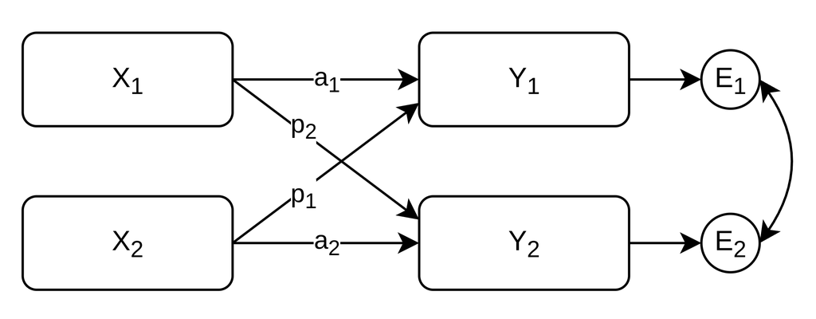

(e.g., Kenny et al., 2006; Kenny & Cook, 1999; Kenny & Kashy, 2011)

## Distinguishable Dyads - Preparing Data

```r
df_apim <- prepare_dyad_data(
  data = df,
  dyad = coupleID,
  member = userID,
  role = gender,
  predictors = communication,
  model_types = "apim",
  keep_compositions = "female-male",
  include_arbitrary_member_contrast = TRUE,
  add_apim_gmc_predictors = TRUE,
  seed = 123
)

print_apim_preview(df_apim)
```

## Distinguishable Dyads - Preparing Data

| userID | coupleID | gender | .is_male | .is_female | .member_contrast_arbitrary | satisfaction | .communication_gmc_actor | .communication_gmc_partner |
| --- | --- | --- | --- | --- | --- | --- | --- | --- |
| 1_1 | 1 | female | 0 | 1 | -1 | 4.841332 | -0.1553604 | 0.9980657 |
| 1_2 | 1 | male | 1 | 0 | 1 | 5.577165 | 0.9980657 | -0.1553604 |
| 2_1 | 2 | female | 0 | 1 | -1 | 7.248741 | 0.8748537 | 1.4272563 |
| 2_2 | 2 | male | 1 | 0 | 1 | 6.960293 | 1.4272563 | 0.8748537 |
| 3_1 | 3 | female | 0 | 1 | -1 | 6.928699 | -0.7224960 | 0.5095933 |
| 3_2 | 3 | male | 1 | 0 | 1 | 6.077688 | 0.5095933 | -0.7224960 |

For the likelihood-based constraint comparison, the glmmTMB models below use `.communication_gmc_actor` and `.communication_gmc_partner`. The Bayesian models retain the raw actor and partner scores, so their intercepts refer to a communication score of 0 rather than the sample mean.

## Distinguishable Dyads - Fitting the Model in glmmTMB

- `glmmTMB` models residual variance/dispersion via `dispformula`, but residual covariance is handled through random-effect covariance structures.
- For Gaussian mixed models, `dispformula = ~ 0` fixes the residual variance to a tiny value. This pushes the Gaussian residual variance into the random-effect block.
- In this Gaussian dyadic model, the `us(0 + .is_male + .is_female | coupleID)` block therefore represents the 2x2 residual variance-covariance structure between partners.
- For non-Gaussian models, this is not an ordinary residual covariance on the response scale. The same random-effect trick adds latent Gaussian heterogeneity/correlation on the linear predictor scale.
- Do **not** use `dispformula = ~ 0` as a general non-Gaussian residual-covariance trick. For families with an estimable dispersion parameter, `dispformula` models that family-specific parameter via a log link; for families without one, such as Poisson or binomial, it is ignored. Partner-specific dispersion, e.g. `dispformula = ~ 0 + .is_male + .is_female`, is only appropriate when the family has a dispersion parameter and this is substantively intended.

## Distinguishable Dyads - Fitting the Model in glmmTMB

```r
model_dist_apim_glmmtmb <- glmmTMB(
  satisfaction ~

    # Remove global intercept, introduce male and female intercepts.
    0 + .is_male + .is_female +

    # Actor effect for male and female
    .communication_gmc_actor:.is_male +
    .communication_gmc_actor:.is_female +

    # Partner effect for male and female
    .communication_gmc_partner:.is_male +
    .communication_gmc_partner:.is_female +

    # Modelling residual non-independence with an unstructured 2x2 covariance.
    us(0 + .is_male + .is_female | coupleID)

    # Gaussian response:
    # dispformula = ~ 0 fixes residual variance to a tiny value,
    # pushing the Gaussian residual variance into this random-effect block.
    , dispformula = ~ 0

    # Non-Gaussian responses:
    # dispformula is family-specific dispersion, or ignored for families
    # without a dispersion parameter. Do not use ~0 as a residual trick.
    # If dispersion exists and should differ by partner, use e.g.:
    # dispformula = ~ 0 + .is_male + .is_female

  , data = df_apim
  , family = gaussian
)
```

## Distinguishable Dyads - Fitting the Model in glmmTMB

Note that ‘unstructured’ is the default in glmmTMB, so instead of

`us(0 + .is_male + .is_female | coupleID)`

we could also remove `us` and simply write

`(0 + .is_male + .is_female | coupleID)`.

An unstructured covariance matrix gives `.is_male` and `.is_female` their own variance and freely estimates their correlation. With more than two members (e.g., triads), it would estimate a separate correlation for every pair.

For two partners, the covariance matrix is:

$$\boldsymbol{\Sigma} =
\begin{pmatrix}
\sigma^2_{female} & \rho\,\sigma_{female}\sigma_{male} \\
\rho\,\sigma_{female}\sigma_{male} & \sigma^2_{male}
\end{pmatrix}.$$

## Distinguishable Dyads - Fitting the Model in glmmTMB

```
 Family: gaussian  ( identity )
Formula:          satisfaction ~ 0 + .is_male + .is_female + .communication_gmc_actor:.is_male +
    .communication_gmc_actor:.is_female + .communication_gmc_partner:.is_male +
    .communication_gmc_partner:.is_female + us(0 + .is_male +      .is_female | coupleID)
Dispersion:                    ~0
Data: df_apim

      AIC       BIC    logLik -2*log(L)  df.resid
   3776.7    3821.7   -1879.3    3758.7      1091

Random effects:

Conditional model:
 Groups   Name       Variance Std.Dev. Corr
 coupleID .is_male   2.559    1.600
          .is_female 1.682    1.297    0.51
Number of obs: 1100, groups:  coupleID, 550

Conditional model:
                                      Estimate Std. Error z value Pr(>|z|)
.is_male                               4.60635    0.06821   67.54  < 2e-16 ***
.is_female                             5.61086    0.05530  101.47  < 2e-16 ***
.is_male:.communication_gmc_actor      1.84363    0.04931   37.39  < 2e-16 ***
.is_female:.communication_gmc_actor    1.59247    0.04112   38.72  < 2e-16 ***
.is_male:.communication_gmc_partner    0.16765    0.05072    3.31 0.000949 ***
.is_female:.communication_gmc_partner  0.31084    0.03997    7.78 7.49e-15 ***
---
Signif. codes:  0 '***' 0.001 '**' 0.01 '*' 0.05 '.' 0.1 ' ' 1
```

## glmmTMB: Diagnostics with Near-Zero Gaussian Sigma

With `dispformula = ~ 0`, `glmmTMB` fixes the Gaussian observation-level residual SD near zero because the dyadic variance and covariance are represented by the random-effect block (Brooks et al., 2017). DHARMa’s default conditional simulation therefore contains almost no observation-level variation. For a marginal check, resimulate the random effects and interpret the result for that target (Hartig, 2026):

```r
dharma_glmmtmb <- DHARMa::simulateResiduals(
  model_dist_apim_glmmtmb,
  n = 1000,
  simulateREs = "unconditional"
)
```

## Distinguishable Dyads - Fitting the Model in brms

In brms, we can use brms-provided residual covariance structures directly. We do not have to set residuals internally to zero.

```r
formula_dist_apim_b <- bf(
  satisfaction ~

    # Remove global intercept, introduce male and female intercepts.
    0 + .is_male + .is_female +

    # Actor effect for male and female
    .communication_actor:.is_male +
    .communication_actor:.is_female +

    # Partner effect for male and female
    .communication_partner:.is_male +
    .communication_partner:.is_female +

    # Gender indexes the two within-couple residual positions.
    unstr(time = gender, gr = coupleID),

  # Allowing two distinct residual variances for males vs females:
  sigma = ~ 0 + .is_male + .is_female

)

priors_dist_apim_b <- c(
  prior(normal(0, 5), class = "b"),
  prior(student_t(3, 0, 1.5), class = "b", dpar = "sigma"),
  prior(lkj(2), class = "cortime")
)

model_dist_apim_b <- brm(
  formula = formula_dist_apim_b,
  data = df_apim,
  family = gaussian(link = identity),
  prior = priors_dist_apim_b,
  chains = 4,
  cores = 4,
  iter = 2000,
  warmup = 1000,
  seed = 123,
  file = file.path('brms_cache', 'example1_dist_apim_b') # Cache the model
)
```

## Distinguishable Dyads - Fitting the Model in brms

```
 Family: gaussian
  Links: mu = identity; sigma = log
Formula: satisfaction ~ 0 + .is_male + .is_female + .communication_actor:.is_male + .communication_actor:.is_female + .communication_partner:.is_male + .communication_partner:.is_female + unstr(time = gender, gr = coupleID)
         sigma ~ 0 + .is_male + .is_female
   Data: df_apim (Number of observations: 1100)
  Draws: 4 chains, each with iter = 2000; warmup = 1000; thin = 1;
         total post-warmup draws = 4000

Correlation Structures:
                     Estimate Est.Error l-95% CI u-95% CI Rhat Bulk_ESS Tail_ESS
cortime(female,male)     0.51      0.03     0.44     0.57 1.00     2895     2470

Regression Coefficients:
                                  Estimate Est.Error l-95% CI u-95% CI Rhat Bulk_ESS Tail_ESS
.is_male                             -5.44      0.28    -5.99    -4.88 1.00     2458     2617
.is_female                           -3.90      0.23    -4.37    -3.47 1.00     2401     2641
.is_male:.communication_actor         1.84      0.05     1.75     1.94 1.00     2678     2997
.is_female:.communication_actor       1.59      0.04     1.51     1.67 1.00     2371     2549
.is_male:.communication_partner       0.17      0.05     0.07     0.26 1.00     2555     2726
.is_female:.communication_partner     0.31      0.04     0.23     0.39 1.00     2398     2724
sigma_.is_male                        0.47      0.03     0.42     0.53 1.00     3555     2827
sigma_.is_female                      0.26      0.03     0.21     0.33 1.00     3317     2788

Draws were sampled using sample(hmc). For each parameter, Bulk_ESS
and Tail_ESS are effective sample size measures, and Rhat is the potential
scale reduction factor on split chains (at convergence, Rhat = 1).
```

## Distinguishable Dyads - Poisson Covariance in brms

Poisson has no separately estimated observation-level residual SD. For distinguishable dyads, we therefore use correlated role-specific dyad effects. The non-Gaussian `unstr()` formulation instead has one common latent SD and would impose equal role variances (Bürkner, 2025). We simulate an actual count outcome rather than discretize continuous `satisfaction`.

## Distinguishable Dyads - Fitting the Poisson Model in brms

```r
formula_dist_apim_c <- bf(
  satisfaction_count ~

    # Remove global intercept, introduce male and female intercepts.
    0 + .is_male + .is_female +

    # Actor effect for male and female
    .communication_actor:.is_male +
    .communication_actor:.is_female +

    # Partner effect for male and female
    .communication_partner:.is_male +
    .communication_partner:.is_female +

    # Model within-dyad dependence with correlated Gaussian random effects.
    # Poisson has no separately estimated residual-dispersion parameter.

    (0 + .is_male + .is_female | coupleID)
)

priors_dist_apim_c <- c(
    prior(normal(0, 5), class = "b"),
    prior(student_t(3, 0, 1.5), class = "sd"),
    prior(lkj(2), class = "cor")
  )

model_dist_apim_c <- brm(
  formula = formula_dist_apim_c,
  data = df_apim_count,
  family = poisson(),
  prior = priors_dist_apim_c,
  chains = 4,
  cores = 4,
  iter = 2000,
  warmup = 1000,
  seed = 123,
  file = file.path('brms_cache', 'example1_dist_apim_c') # Cache the model
)
```

## Poisson Model in brms: Results

```
 Family: poisson
  Links: mu = log
Formula: satisfaction_count ~ 0 + .is_male + .is_female + .communication_actor:.is_male + .communication_actor:.is_female + .communication_partner:.is_male + .communication_partner:.is_female + (0 + .is_male + .is_female | coupleID)
   Data: df_apim_count (Number of observations: 1100)
  Draws: 4 chains, each with iter = 2000; warmup = 1000; thin = 1;
         total post-warmup draws = 4000

Multilevel Hyperparameters:
~coupleID (Number of levels: 550)
                         Estimate Est.Error l-95% CI u-95% CI Rhat Bulk_ESS Tail_ESS
sd(.is_male)                 0.38      0.03     0.33     0.43 1.00     1771     2547
sd(.is_female)               0.27      0.03     0.22     0.32 1.00     1868     2480
cor(.is_male,.is_female)     0.30      0.11     0.08     0.52 1.00     1107     2003

Regression Coefficients:
                                  Estimate Est.Error l-95% CI u-95% CI Rhat Bulk_ESS Tail_ESS
.is_male                              0.47      0.11     0.27     0.68 1.00     2639     2753
.is_female                            0.64      0.09     0.46     0.81 1.00     3087     2953
.is_male:.communication_actor         0.21      0.02     0.17     0.25 1.00     2587     3041
.is_female:.communication_actor       0.17      0.02     0.14     0.20 1.00     2933     2656
.is_male:.communication_partner       0.01      0.02    -0.03     0.04 1.00     2519     2720
.is_female:.communication_partner     0.06      0.01     0.03     0.09 1.00     3308     2926

Draws were sampled using sample(hmc). For each parameter, Bulk_ESS
and Tail_ESS are effective sample size measures, and Rhat is the potential
scale reduction factor on split chains (at convergence, Rhat = 1).
```

## Distinguishable Dyads - Fitting the Model in glmmTMB

```r
model_glmmTMB_dist_apim_c <- glmmTMB(
  satisfaction_count ~

    # Remove global intercept, introduce male and female intercepts.
    0 + .is_male + .is_female +

    # Actor effect for male and female
    .communication_actor:.is_male +
    .communication_actor:.is_female +

    # Partner effect for male and female
    .communication_partner:.is_male +
    .communication_partner:.is_female +

    # Model within-dyad dependence with correlated Gaussian random effects.
    # Poisson has no separately estimated residual-dispersion parameter.

    (0 + .is_male + .is_female | coupleID)
  , data = df_apim_count
  , family = poisson()
)
```

## Poisson Model in glmmTMB: Results

```
 Family: poisson  ( log )
Formula:          satisfaction_count ~ 0 + .is_male + .is_female + .communication_actor:.is_male +
    .communication_actor:.is_female + .communication_partner:.is_male +
    .communication_partner:.is_female + (0 + .is_male + .is_female |      coupleID)
Data: df_apim_count

      AIC       BIC    logLik -2*log(L)  df.resid
     5434      5479     -2708      5416      1091

Random effects:

Conditional model:
 Groups   Name       Variance Std.Dev. Corr
 coupleID .is_male   0.14072  0.3751
          .is_female 0.07157  0.2675   0.30
Number of obs: 1100, groups:  coupleID, 550

Conditional model:
                                  Estimate Std. Error z value Pr(>|z|)
.is_male                           0.47400    0.10744   4.412 1.02e-05 ***
.is_female                         0.63559    0.08969   7.087 1.37e-12 ***
.is_male:.communication_actor      0.20833    0.01815  11.476  < 2e-16 ***
.is_female:.communication_actor    0.17450    0.01541  11.322  < 2e-16 ***
.is_male:.communication_partner    0.00901    0.01854   0.486 0.626980
.is_female:.communication_partner  0.05710    0.01481   3.856 0.000115 ***
---
Signif. codes:  0 '***' 0.001 '**' 0.01 '*' 0.05 '.' 0.1 ' ' 1
```

## Distinguishable Dyads - Check Model Convergence and Fit

Check Rhats and Effective Sample Sizes (ESS_tail and ESS_bulk) directly from the brms summary: Rhat should be below 1.01 and both ESS above 400. Some longitudinal example fits below fall short of this (Rhat up to 1.05); for real analyses, run more iterations. Additionally you can (using Model B as an example):

```r
# In brms 2.23, draws from either Stan backend are stored as a stanfit here.
rstan::check_hmc_diagnostics(model_dist_apim_b$fit)
```

```
Divergences:
```

```
0 of 4000 iterations ended with a divergence.
```

```
Tree depth:
```

```
0 of 4000 iterations saturated the maximum tree depth of 10.
```

```
Energy:
```

```
E-BFMI indicated no pathological behavior.
```

## Distinguishable Dyads - Check Model Convergence and Fit

```r
plot(model_dist_apim_b, ask = FALSE)
```

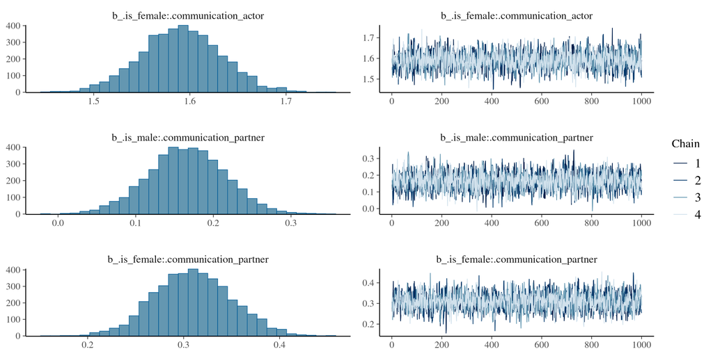

## Distinguishable Dyads - Check Model Convergence and Fit

```r
pp_check(model_dist_apim_b, 'dens_overlay_grouped', group = '.is_male')
```

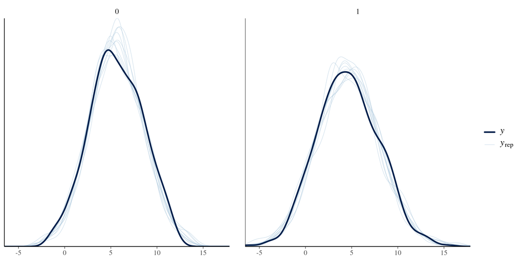

## Distinguishable Dyads - Check Model Convergence and Fit

```r
pp_check(model_dist_apim_b, 'ecdf_overlay_grouped', group = '.is_male')
```

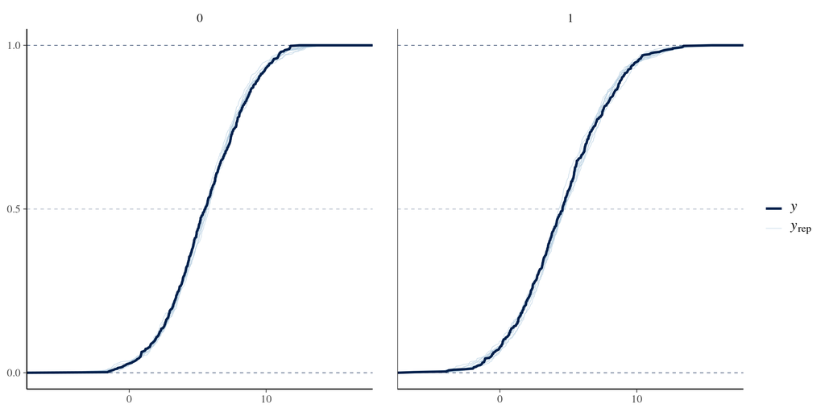

## Distinguishable Dyads - Check Model Convergence and Fit

```r
# Custom function to make DHARMa work with brms (see file 'Functions')
DHARMa.check_brms(model_dist_apim_b)
```

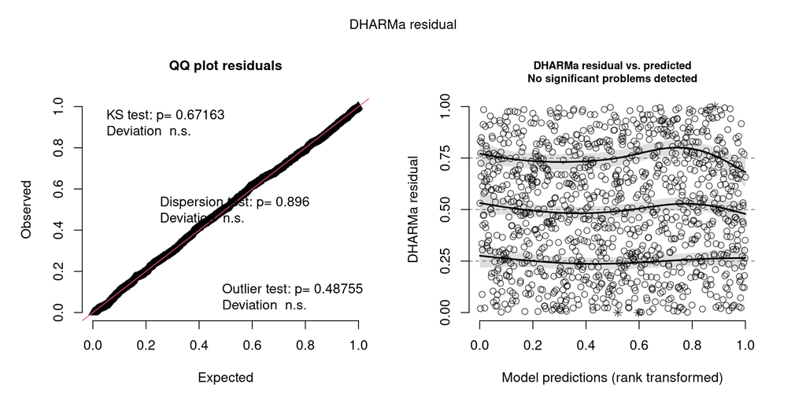

## Distinguishable Dyads - Check Model Convergence and Fit

- Diagnose convergence, residual fit, and predictive accuracy separately; check coding, scaling, priors, and identifiability before changing the model.
- Choose the family and link from the outcome and substantive assumptions—for example, `cumulative()` for ordered outcomes or `bernoulli()` for binary data.
- If chains are healthy, more post-warmup draws can raise ESS. More warmup helps adaptation, while higher `adapt_delta` specifically targets divergences (Bürkner, 2025).

## Excursion: Generalized Dyadic Models

For Gaussian outcomes, residual covariance has a direct response-scale interpretation:

- partner-specific residual variances
- partner residual correlations
- same-day residual covariance in ILD data

For non-Gaussian outcomes, the same syntax usually does **not** estimate an ordinary residual covariance.

Instead, random-effect covariance terms represent latent Gaussian heterogeneity on the link scale.

## Excursion: Count vs Binary Outcomes

For count outcomes, latent partner covariance is often useful and can be estimable:

- Poisson or negative-binomial models can include dyad-level latent covariance terms
- estimates live on the log-link scale
- covariance parameters need diagnostics and sensitivity checks

For dichotomous outcomes, the same idea is much harder:

- each partner contributes only `0` or `1` per occasion
- many latent variance-correlation combinations can imply similar pair probabilities
- same-day binary covariance is especially weakly identified

## Excursion: Practical Warning

Binary dyadic covariance models can converge mechanically while still being unreliable.

Watch for:

- variance estimates near zero or extremely large
- correlations near `-1` or `1`
- low ESS, divergent transitions, or strong prior sensitivity
- different software giving very different covariance estimates

## Excursion: Practical Strategy

Practical default:

- estimate simpler structures first
- use informative priors if fitting latent binary covariance in brms
- treat same-day binary partner covariance as a specialized model, not a routine extension
- if the main goal is fixed effects, consider simpler random effects or robust/clustered inference

## Distinguishable Dyads - Results

|  | Est. | 95% CI | Rhat | Bulk_ESS | Tail_ESS |
| --- | --- | --- | --- | --- | --- |
| **Fixed Effects** |  |  |  |  |  |
| .is_male | -5.44 | [-5.99, -4.88] | 1.003 | 2458 | 2617 |
| .is_female | -3.90 | [-4.37, -3.47] | 1.001 | 2401 | 2641 |
| .is_male:.communication_actor | 1.84 | [ 1.75, 1.94] | 1.000 | 2678 | 2997 |
| .is_female:.communication_actor | 1.59 | [ 1.51, 1.67] | 1.001 | 2371 | 2549 |
| .is_male:.communication_partner | 0.17 | [ 0.07, 0.26] | 1.001 | 2555 | 2726 |
| .is_female:.communication_partner | 0.31 | [ 0.23, 0.39] | 1.000 | 2398 | 2724 |
| **Residual Structure** |  |  |  |  |  |
| cortime(female,male) | 0.51 | [0.44, 0.57] | 1.000 | 2895 | 2470 |
| sigma_.is_male | 1.60 | [1.51, 1.71] | 1.000 | 3555 | 2827 |
| sigma_.is_female | 1.30 | [1.23, 1.39] | 1.001 | 3317 | 2788 |

NOTE: brms estimates sigma on the log scale. In the tables, sigmas are exponentiated to show residual SDs on the response scale, like glmmTMB output.

# Distinguishable Dyads

# Distinguishable Dyads - Intensive Longitudinal APIM (L-APIM)

## Distinguishable Dyads - L-APIM - Raw Data

```r
print_df(head(df_long))
```

| userID | coupleID | diaryday | gender | closeness | provided_support |
| --- | --- | --- | --- | --- | --- |
| 1_1 | 1 | 0 | female | 5.659395 | 4.733482 |
| 1_1 | 1 | 1 | female | 7.249842 | 5.019950 |
| 1_1 | 1 | 2 | female | 6.040587 | 5.365179 |
| 1_1 | 1 | 3 | female | 6.898253 | 5.148704 |
| 1_1 | 1 | 4 | female | 5.350049 | 3.702039 |
| 1_1 | 1 | 5 | female | 6.191282 | 4.844602 |

## Distinguishable Dyads - L-APIM - Data Preparation

```r
df_long_apim <- prepare_dyad_data(
  data = df_long,
  dyad = coupleID,
  member = userID,
  role = gender,
  time = diaryday,
  predictors = provided_support,
  model_types = "apim"
) %>%
  mutate(
    diaryday_c = diaryday - mean(diaryday)
  )
```

## Distinguishable Dyads - L-APIM - Prepared Data

| userID | coupleID | diaryday | gender | closeness | provided_support | .composition | .composition_role | .is_female | .is_male | .provided_support_cwp | .provided_support_cbp | .provided_support_actor | .provided_support_partner | .provided_support_cwp_actor | .provided_support_cwp_partner | .provided_support_cbp_actor | .provided_support_cbp_partner | diaryday_c |
| --- | --- | --- | --- | --- | --- | --- | --- | --- | --- | --- | --- | --- | --- | --- | --- | --- | --- | --- |
| 31_1 | 31 | 0 | female | 5.47 | 6.02 | female_x_male | female_x_male_female | 1 | 0 | 0.41 | 0.65 | 6.02 | 7.09 | 0.41 | 1.54 | 0.65 | 0.58 | -27 |
| 31_1 | 31 | 1 | female | 7.69 | 6.13 | female_x_male | female_x_male_female | 1 | 0 | 0.51 | 0.65 | 6.13 | 6.95 | 0.51 | 1.4 | 0.65 | 0.58 | -26 |
| 31_1 | 31 | 2 | female | 5.83 | 6.1 | female_x_male | female_x_male_female | 1 | 0 | 0.49 | 0.65 | 6.1 | 6.34 | 0.49 | 0.79 | 0.65 | 0.58 | -25 |
| 31_1 | 31 | 3 | female | 6.55 | 6.99 | female_x_male | female_x_male_female | 1 | 0 | 1.38 | 0.65 | 6.99 | 5.39 | 1.38 | -0.15 | 0.65 | 0.58 | -24 |
| ... | ... | ... | ... | ... | ... | ... | ... | ... | ... | ... | ... | ... | ... | ... | ... | ... | ... | ... |
| 31_2 | 31 | 0 | male | 5.19 | 7.09 | female_x_male | female_x_male_male | 0 | 1 | 1.54 | 0.58 | 7.09 | 6.02 | 1.54 | 0.41 | 0.58 | 0.65 | -27 |
| 31_2 | 31 | 1 | male | 6.96 | 6.95 | female_x_male | female_x_male_male | 0 | 1 | 1.4 | 0.58 | 6.95 | 6.13 | 1.4 | 0.51 | 0.58 | 0.65 | -26 |
| 31_2 | 31 | 2 | male | 6.9 | 6.34 | female_x_male | female_x_male_male | 0 | 1 | 0.79 | 0.58 | 6.34 | 6.1 | 0.79 | 0.49 | 0.58 | 0.65 | -25 |
| 31_2 | 31 | 3 | male | 7.59 | 5.39 | female_x_male | female_x_male_male | 0 | 1 | -0.15 | 0.58 | 5.39 | 6.99 | -0.15 | 1.38 | 0.58 | 0.65 | -24 |

## Distinguishable Dyads - L-APIM - Centering

With repeated measures we need to center variables in order to not conflate levels of analysis (Bolger & Laurenceau, 2013):

- Between-Person: The person-mean in relation to the grand mean
- Within-Person: Daily fluctuations of an individual from their person-mean

Although the data contain couple, person, and day structure, the APIM is written at the person-day level after decomposing predictors into between-person and within-person components. Dyad-level dependence is still modelled explicitly through partner-specific random effects and residual covariance structures.

## Distinguishable Dyads - L-APIM - Centering

`prepare_dyad_data()` performs this predictor decomposition before creating the actor and partner columns. The centered `diaryday_c` variable above is a separate time transformation for the models, not part of the dyadic predictor construction.

## Distinguishable Dyads - L-APIM - Model nlme

`nlme` model of this data for reference (simplified random effects structure to achieve convergence).

This package is old, but still often used and cited. So here, we briefly show it to demonstrate that we can achieve the same model with much more modern and powerful methods.

```r
library(nlme)

model1 <- lme(
  fixed =
    # Intercepts
    closeness ~ 0 + .is_male + .is_female +

    # Time Slopes
    .is_male:diaryday_c +
    .is_female:diaryday_c +

    # Between-Person APIM
    .is_male:.provided_support_cbp_actor +
    .is_male:.provided_support_cbp_partner +

    .is_female:.provided_support_cbp_actor +
    .is_female:.provided_support_cbp_partner +

    # Within-Person APIM
    .is_male:.provided_support_cwp_actor +
    .is_male:.provided_support_cwp_partner +

    .is_female:.provided_support_cwp_actor +
    .is_female:.provided_support_cwp_partner,

  random =
    ~ 0 + .is_male + .is_female

    + .is_male:diaryday_c + .is_female:diaryday_c

  # in nlme we need to remove many random slopes to achieve convergence
  # alternatively, we could try to remove correlations between the slopes.
    #+ .is_male:.provided_support_cwp_actor
    #+ .is_male:.provided_support_cwp_partner
    #+ .is_female:.provided_support_cwp_actor
    #+ .is_female:.provided_support_cwp_partner
  | coupleID,

  weights = varIdent(form = ~ 1 | gender), # heterogeneous residual variances
  corr = corCompSymm(form = ~ 1 | coupleID/diaryday), # compound symmetry (partner's values on each day)

  data = df_long_apim,
  control = list(maxIter=1000)
)

summary(model1)
```

## Distinguishable Dyads - L-APIM - Model glmmTMB

```r
model_dist_apim_long_glmmtmb <- glmmTMB(
  closeness ~ 0 + .is_male + .is_female +

    # Time Slopes
    .is_male:diaryday_c +
    .is_female:diaryday_c +

    # Between-Person APIM
    .is_male:.provided_support_cbp_actor +
    .is_male:.provided_support_cbp_partner +

    .is_female:.provided_support_cbp_actor +
    .is_female:.provided_support_cbp_partner +

    # Within-Person APIM
    .is_male:.provided_support_cwp_actor +
    .is_male:.provided_support_cwp_partner +

    .is_female:.provided_support_cwp_actor +
    .is_female:.provided_support_cwp_partner +

  # Accounting for non-independence between partners' means and trajectories
  # via random effects:
  (0 + .is_male + .is_female
    + .is_male:diaryday_c + .is_female:diaryday_c
  | coupleID) +

  # Accounting for daily non-independence
  us(0 + .is_male + .is_female | coupleID:diaryday)

  # no separate residual term: the us() block above models the residuals
  , dispformula = ~ 0
  , data = df_long_apim
)
```

## Distinguishable Dyads - L-APIM - Model glmmTMB

```
 Family: gaussian  ( identity )
Formula:          closeness ~ 0 + .is_male + .is_female + .is_male:diaryday_c +
    .is_female:diaryday_c + .is_male:.provided_support_cbp_actor +
    .is_male:.provided_support_cbp_partner + .is_female:.provided_support_cbp_actor +
    .is_female:.provided_support_cbp_partner + .is_male:.provided_support_cwp_actor +
    .is_male:.provided_support_cwp_partner + .is_female:.provided_support_cwp_actor +
    .is_female:.provided_support_cwp_partner + (0 + .is_male +
    .is_female + .is_male:diaryday_c + .is_female:diaryday_c |
    coupleID) + us(0 + .is_male + .is_female | coupleID:diaryday)
Dispersion:                 ~0
Data: df_long_apim

      AIC       BIC    logLik -2*log(L)  df.resid
  30001.8   30184.4  -14975.9   29951.8     10975

Random effects:

Conditional model:
 Groups            Name                  Variance  Std.Dev. Corr
 coupleID          .is_male              0.6813649 0.82545
                   .is_female            0.7929829 0.89050   0.19
                   .is_male:diaryday_c   0.0002637 0.01624   0.55  0.03
                   .is_female:diaryday_c 0.0002571 0.01603   0.21  0.54 -0.01
 coupleID:diaryday .is_male              1.2583395 1.12176
                   .is_female            0.5206603 0.72157  0.04
Number of obs: 11000, groups:  coupleID, 100; coupleID:diaryday, 5500

Conditional model:
                                          Estimate Std. Error z value Pr(>|z|)
.is_male                                  4.486375   0.085960   52.19  < 2e-16 ***
.is_female                                5.736720   0.091763   62.52  < 2e-16 ***
.is_male:diaryday_c                      -0.003258   0.001883   -1.73  0.08355 .
.is_female:diaryday_c                     0.010606   0.001717    6.18 6.46e-10 ***
.is_male:.provided_support_cbp_actor      1.128018   0.101922   11.07  < 2e-16 ***
.is_male:.provided_support_cbp_partner    0.298902   0.098817    3.02  0.00249 **
.is_female:.provided_support_cbp_actor    1.380753   0.105607   13.07  < 2e-16 ***
.is_female:.provided_support_cbp_partner  0.587254   0.108927    5.39 7.00e-08 ***
.is_male:.provided_support_cwp_actor      0.184479   0.020564    8.97  < 2e-16 ***
.is_male:.provided_support_cwp_partner    0.124548   0.020571    6.05 1.41e-09 ***
.is_female:.provided_support_cwp_actor    0.419162   0.013277   31.57  < 2e-16 ***
.is_female:.provided_support_cwp_partner  0.170127   0.013270   12.82  < 2e-16 ***
---
Signif. codes:  0 '***' 0.001 '**' 0.01 '*' 0.05 '.' 0.1 ' ' 1
```

## Comparing outputs between nlme and glmmTMB

Let’s compare the random effects outputs to see if the models are truly equivalent.

Residual variance in `nlme` must first be constructed from the output by taking the residual SD and multiplying it by the parameter estimate under the variance function for each partner.

**nlme:**

```
                     StdDev     Corr
.is_male              0.83645552 is_mal is_fml is_m:_
.is_female            0.90199634  0.189
.is_male:diaryday_c   0.01634796  0.544  0.033
.is_female:diaryday_c 0.01612665  0.204  0.534 -0.012
Residual             0.72170702

Correlation Structure: Compound symmetry
 Formula: ~1 | coupleID/diaryday
 Parameter estimate(s):
       Rho
0.04094751
Variance function:
 Structure: Different standard deviations per stratum
 Formula: ~1 | gender
 Parameter estimates:
       1        2
1.000000 1.554608



Manually computed by multiplying the residual SD by the multipliers:

Residual SDs by partner:
  Partner 1: 0.721707
  Partner 2: 1.121972
```

**glmmTMB:**

```
Random effects:
Conditional model:
 Groups            Name                 Variance  Std.Dev. Corr
 coupleID          .is_male              0.6814498 0.82550
                   .is_female            0.7930407 0.89053   0.19
                   .is_male:diaryday_c   0.0002637 0.01624   0.55  0.03
                   .is_female:diaryday_c 0.0002571 0.01603   0.21  0.54 -0.01
 coupleID:diaryday .is_male              1.2583552 1.12176
                   .is_female            0.5206608 0.72157  0.04
```

## Distinguishable Dyads - L-APIM - Model brms

Equivalent `brms` model.

In contrast to glmmTMB, brms provides native variance-covariance structures to model residuals directly. Therefore, we do NOT set the residuals to zero!

```r
formula_dist_apim_long_simple <- bf(
  closeness ~ 0 + .is_male + .is_female +

    # Time Slopes
    .is_male:diaryday_c +
    .is_female:diaryday_c +

    # Between-Person APIM
    .is_male:.provided_support_cbp_actor +
    .is_male:.provided_support_cbp_partner +

    .is_female:.provided_support_cbp_actor +
    .is_female:.provided_support_cbp_partner +

    # Within-Person APIM
    .is_male:.provided_support_cwp_actor +
    .is_male:.provided_support_cwp_partner +

    .is_female:.provided_support_cwp_actor +
    .is_female:.provided_support_cwp_partner +

  # Accounting for non-independence between partners' means and trajectories
  # via random effects:
  (0 + .is_male + .is_female
    + .is_male:diaryday_c + .is_female:diaryday_c
  | coupleID) +

  # Gender indexes the two partner residual positions within each couple-day.
  unstr(time = gender, gr = coupleID:diaryday)

  # heteroscedastic residuals
  , sigma ~ 0 + .is_male + .is_female
)

# brms' defaults for group-level SDs and correlations are sensible weak defaults
# (half Student-t priors for SDs and LKJ priors for correlation matrices). Here we
# set weakly regularizing priors explicitly so the modelling assumptions are visible.

priors_dist_apim_long_simple <- c(
  prior(normal(4, 2), class = "b", coef = ".is_male"), # male intercept
  prior(normal(4, 2), class = "b", coef = ".is_female"), # female intercept
  prior(normal(0, 2), class = "b"), # other beta coefficients
  prior(exponential(1), class = "sd"),
  prior(lkj(2), class = "cor"),
  prior(normal(0, 0.7), class = "b", dpar = "sigma"),
  prior(lkj(2), class = "cortime")
)

model_dist_apim_long_simple <- brm(
  formula = formula_dist_apim_long_simple,
  data = df_long_apim,
  family = gaussian(link = identity), # student() is also often a nice robust option.
  prior = priors_dist_apim_long_simple,
  chains = 4,
  cores = 4,
  iter = 2000,
  warmup = 1000,
  seed = 123,
  file = file.path('brms_cache', 'example1_dist_apim_long_simpel') # Cache the model
)
```

## Distinguishable Dyads - L-APIM - Results (scrollable)

|  | Est. | 95% CI | Rhat | Bulk_ESS | Tail_ESS |
| --- | --- | --- | --- | --- | --- |
| **Fixed Effects** |  |  |  |  |  |
| .is_male | 4.49 | [ 4.32, 4.65] | 1.007 | 324 | 794 |
| .is_female | 5.74 | [ 5.56, 5.91] | 1.009 | 355 | 656 |
| .is_male:diaryday_c | 0.00 | [-0.01, 0.00] | 1.007 | 1072 | 2113 |
| .is_female:diaryday_c | 0.01 | [ 0.01, 0.01] | 1.002 | 880 | 1778 |
| .is_male:.provided_support_cbp_actor | 1.14 | [ 0.91, 1.34] | 1.006 | 489 | 791 |
| .is_male:.provided_support_cbp_partner | 0.30 | [ 0.10, 0.51] | 1.004 | 553 | 716 |
| .is_female:.provided_support_cbp_actor | 1.38 | [ 1.18, 1.58] | 1.005 | 507 | 1077 |
| .is_female:.provided_support_cbp_partner | 0.60 | [ 0.36, 0.81] | 1.005 | 440 | 851 |
| .is_male:.provided_support_cwp_actor | 0.18 | [ 0.14, 0.23] | 1.000 | 5328 | 3057 |
| .is_male:.provided_support_cwp_partner | 0.12 | [ 0.08, 0.16] | 1.003 | 7228 | 3389 |
| .is_female:.provided_support_cwp_actor | 0.42 | [ 0.39, 0.45] | 1.002 | 5990 | 3068 |
| .is_female:.provided_support_cwp_partner | 0.17 | [ 0.14, 0.20] | 1.001 | 5829 | 3105 |
| **Random Effects** |  |  |  |  |  |
| sd(.is_male) | 0.84 | [ 0.73, 0.97] | 1.010 | 520 | 1077 |
| sd(.is_female) | 0.92 | [ 0.80, 1.06] | 1.006 | 556 | 998 |
| sd(.is_male:diaryday_c) | 0.02 | [ 0.01, 0.02] | 1.001 | 1744 | 2637 |
| sd(.is_female:diaryday_c) | 0.02 | [ 0.01, 0.02] | 1.001 | 1358 | 2043 |
| cor(.is_male,.is_female) | 0.18 | [-0.05, 0.35] | 1.010 | 321 | 688 |
| cor(.is_male,.is_male:diaryday_c) | 0.51 | [ 0.32, 0.67] | 1.004 | 1528 | 1804 |
| cor(.is_female,.is_male:diaryday_c) | 0.03 | [-0.21, 0.24] | 1.002 | 1315 | 2204 |
| cor(.is_male,.is_female:diaryday_c) | 0.19 | [-0.01, 0.38] | 1.003 | 753 | 1691 |
| cor(.is_female,.is_female:diaryday_c) | 0.51 | [ 0.33, 0.65] | 1.002 | 1073 | 1832 |
| cor(.is_male:diaryday_c,.is_female:diaryday_c) | -0.02 | [-0.25, 0.22] | 1.008 | 867 | 1748 |
| **Residual Structure** |  |  |  |  |  |
| cortime(female,male) | 0.04 | [ 0.01, 0.07] | 1.000 | 6904 | 3067 |
| sigma_.is_male | 1.12 | [ 1.10, 1.14] | 1.001 | 6996 | 2514 |
| sigma_.is_female | 0.72 | [ 0.71, 0.74] | 0.999 | 6880 | 2868 |

Note: Sigma rows are shown on the response scale; they were exponentiated from brms’ log-sigma parameterization.

## Distinguishable Dyads - L-APIM - AR(1)?

In this model, `unstr(time = gender, gr = coupleID:diaryday)` handles same-day partner interdependence. Current univariate `brms` models cannot combine this residual correlation structure with `ar()` in the same formula (Bürkner, 2025).

Standard `glmmTMB` can add a same-day dyadic block and independent person-specific AR(1) processes:

```r
us(0 + gender | coupleID:diaryday) +
  ar1(0 + diaryday_factor | userID)
```

This additive model represents same-day dyadic shocks plus person-specific persistence. It splits lag-zero variance across the two blocks. These residual blocks contribute zero cross-partner covariance across different days, although dyad-level random effects can still induce cross-day covariance; this is not one separable partner-by-time residual process (Brooks et al., 2017).

## Excursion: Dynamic Workaround

A dynamic MLM can account for temporal dependence by including lagged within-person centered outcomes as predictors (include both actor inertia and partner spillover).

But:

- The APIM coefficients become effects conditional on prior closeness, not total within-person associations.
- Lagged-outcome models can also suffer from dynamic-panel bias, often called Nickell bias (Nickell, 1981), because the lagged outcome is related to person/couple effects and prior residuals. This is especially problematic with short time series.
  - One solution for the Nickell bias is to use multilevel DSEM through MPLUS.

## Maximal Model Specification (non-dynamic/no AR(1))

We add all random slopes and their correlations. This is neither converging in `nlme` nor `glmmTMB`.

```r
formula_dist_apim_long_complex <- bf(
  closeness ~

    # Intercepts
    0 + .is_male + .is_female +

    # Time Slopes
    .is_male:diaryday_c +
    .is_female:diaryday_c +

    # Between-Person APIM
    .is_male:.provided_support_cbp_actor +
    .is_male:.provided_support_cbp_partner +

    .is_female:.provided_support_cbp_actor +
    .is_female:.provided_support_cbp_partner +

    # Within-Person APIM
    .is_male:.provided_support_cwp_actor +
    .is_male:.provided_support_cwp_partner +

    .is_female:.provided_support_cwp_actor +
    .is_female:.provided_support_cwp_partner +

    # Accounting for non-independence between partners' means and trajectories
    # and effect sensitivities via random effects:
    (0 + .is_male + .is_female +

       .is_male:diaryday_c + .is_female:diaryday_c +

       .is_male:.provided_support_cwp_actor +
       .is_male:.provided_support_cwp_partner +
       .is_female:.provided_support_cwp_actor +
       .is_female:.provided_support_cwp_partner
    | coupleID ) +

    # Accounting for daily non-independence
    unstr(time = gender, gr = coupleID:diaryday),

  sigma ~ 0 + .is_male + .is_female   # heteroscedastic residuals
)

priors_dist_apim_long_complex <- c(
  prior(normal(4, 2), class = "b", coef = ".is_male"),
  prior(normal(4, 2), class = "b", coef = ".is_female"),
  prior(normal(0, 2), class = "b"),
  prior(exponential(1), class = "sd"),
  prior(lkj(2), class = "cor"),
  prior(normal(0, 0.7), class = "b", dpar = "sigma"),
  prior(lkj(2), class = "cortime")
)


model_dist_apim_long_complex <- brm(
  formula = formula_dist_apim_long_complex,
  data = df_long_apim,
  family = gaussian(link = identity),
  prior = priors_dist_apim_long_complex,
  chains = 4,
  cores = 4,
  iter = 2000,
  warmup = 1000,
  seed = 123,
  file = file.path('brms_cache', 'example1_dist_apim_long_complex') # Cache the model
)
```

## Maximal Model Specification: Results

|  | Est. | 95% CI | Rhat | Bulk_ESS | Tail_ESS |
| --- | --- | --- | --- | --- | --- |
| **Fixed Effects** |  |  |  |  |  |
| .is_male | 4.49 | [ 4.31, 4.67] | 1.006 | 334 | 722 |
| .is_female | 5.73 | [ 5.54, 5.92] | 1.006 | 271 | 770 |
| .is_male:diaryday_c | 0.00 | [-0.01, 0.00] | 1.002 | 1249 | 1965 |
| .is_female:diaryday_c | 0.01 | [ 0.01, 0.01] | 1.005 | 840 | 2033 |
| .is_male:.provided_support_cbp_actor | 1.12 | [ 0.92, 1.32] | 1.004 | 688 | 1529 |
| .is_male:.provided_support_cbp_partner | 0.31 | [ 0.10, 0.51] | 1.002 | 656 | 1267 |
| .is_female:.provided_support_cbp_actor | 1.37 | [ 1.16, 1.59] | 1.002 | 491 | 987 |
| .is_female:.provided_support_cbp_partner | 0.60 | [ 0.35, 0.82] | 1.003 | 432 | 740 |
| .is_male:.provided_support_cwp_actor | 0.18 | [ 0.14, 0.23] | 1.000 | 5755 | 3046 |
| .is_male:.provided_support_cwp_partner | 0.13 | [ 0.08, 0.18] | 1.000 | 6028 | 3158 |
| .is_female:.provided_support_cwp_actor | 0.42 | [ 0.39, 0.45] | 1.000 | 5549 | 3243 |
| .is_female:.provided_support_cwp_partner | 0.17 | [ 0.14, 0.20] | 1.000 | 5548 | 3014 |
| **Random Effects** |  |  |  |  |  |
| sd(.is_male) | 0.85 | [ 0.74, 0.98] | 1.002 | 857 | 1449 |
| sd(.is_female) | 0.91 | [ 0.79, 1.05] | 1.006 | 515 | 1265 |
| sd(.is_male:diaryday_c) | 0.02 | [ 0.01, 0.02] | 1.000 | 1973 | 2634 |
| sd(.is_female:diaryday_c) | 0.02 | [ 0.01, 0.02] | 1.001 | 1361 | 2175 |
| sd(.is_male:.provided_support_cwp_actor) | 0.09 | [ 0.02, 0.15] | 1.002 | 1162 | 1085 |
| sd(.is_male:.provided_support_cwp_partner) | 0.14 | [ 0.06, 0.20] | 1.000 | 1012 | 947 |
| sd(.is_female:.provided_support_cwp_actor) | 0.08 | [ 0.02, 0.12] | 1.004 | 923 | 905 |
| sd(.is_female:.provided_support_cwp_partner) | 0.06 | [ 0.01, 0.10] | 1.001 | 1002 | 1720 |
| cor(.is_male,.is_female) | 0.15 | [-0.04, 0.34] | 1.022 | 350 | 819 |
| cor(.is_male,.is_male:diaryday_c) | 0.48 | [ 0.28, 0.63] | 1.001 | 2211 | 2867 |
| cor(.is_female,.is_male:diaryday_c) | 0.00 | [-0.20, 0.22] | 1.003 | 1801 | 3156 |
| cor(.is_male,.is_female:diaryday_c) | 0.17 | [-0.03, 0.36] | 1.005 | 940 | 2321 |
| cor(.is_female,.is_female:diaryday_c) | 0.49 | [ 0.30, 0.64] | 1.008 | 1172 | 2078 |
| cor(.is_male:diaryday_c,.is_female:diaryday_c) | -0.03 | [-0.26, 0.19] | 1.003 | 1108 | 1730 |
| cor(.is_male,.is_male:.provided_support_cwp_actor) | 0.37 | [-0.06, 0.70] | 1.001 | 4857 | 2732 |
| cor(.is_female,.is_male:.provided_support_cwp_actor) | 0.19 | [-0.22, 0.57] | 1.003 | 5018 | 2783 |
| cor(.is_male:diaryday_c,.is_male:.provided_support_cwp_actor) | 0.33 | [-0.13, 0.68] | 1.001 | 5222 | 3270 |
| cor(.is_female:diaryday_c,.is_male:.provided_support_cwp_actor) | 0.27 | [-0.17, 0.64] | 1.000 | 4899 | 2758 |
| cor(.is_male,.is_male:.provided_support_cwp_partner) | 0.06 | [-0.26, 0.38] | 1.000 | 5278 | 3217 |
| cor(.is_female,.is_male:.provided_support_cwp_partner) | 0.10 | [-0.22, 0.43] | 1.001 | 4991 | 2571 |
| cor(.is_male:diaryday_c,.is_male:.provided_support_cwp_partner) | 0.04 | [-0.31, 0.40] | 1.000 | 4298 | 2455 |
| cor(.is_female:diaryday_c,.is_male:.provided_support_cwp_partner) | 0.11 | [-0.22, 0.45] | 1.000 | 4766 | 2466 |
| cor(.is_male:.provided_support_cwp_actor,.is_male:.provided_support_cwp_partner) | 0.24 | [-0.27, 0.68] | 1.005 | 1124 | 2137 |
| cor(.is_male,.is_female:.provided_support_cwp_actor) | -0.06 | [-0.44, 0.29] | 1.001 | 4620 | 2478 |
| cor(.is_female,.is_female:.provided_support_cwp_actor) | 0.21 | [-0.17, 0.55] | 1.000 | 4730 | 2276 |
| cor(.is_male:diaryday_c,.is_female:.provided_support_cwp_actor) | -0.14 | [-0.51, 0.25] | 1.001 | 4056 | 3026 |
| cor(.is_female:diaryday_c,.is_female:.provided_support_cwp_actor) | -0.07 | [-0.43, 0.30] | 1.000 | 5099 | 3132 |
| cor(.is_male:.provided_support_cwp_actor,.is_female:.provided_support_cwp_actor) | -0.17 | [-0.61, 0.37] | 1.002 | 1540 | 2245 |
| cor(.is_male:.provided_support_cwp_partner,.is_female:.provided_support_cwp_actor) | -0.10 | [-0.56, 0.40] | 1.001 | 2566 | 2969 |
| cor(.is_male,.is_female:.provided_support_cwp_partner) | 0.27 | [-0.21, 0.63] | 1.000 | 5732 | 2872 |
| cor(.is_female,.is_female:.provided_support_cwp_partner) | 0.07 | [-0.37, 0.48] | 1.000 | 5615 | 2735 |
| cor(.is_male:diaryday_c,.is_female:.provided_support_cwp_partner) | 0.12 | [-0.34, 0.53] | 1.000 | 5813 | 3459 |
| cor(.is_female:diaryday_c,.is_female:.provided_support_cwp_partner) | 0.15 | [-0.31, 0.56] | 1.002 | 5869 | 2966 |
| cor(.is_male:.provided_support_cwp_actor,.is_female:.provided_support_cwp_partner) | 0.16 | [-0.39, 0.64] | 1.001 | 2540 | 3043 |
| cor(.is_male:.provided_support_cwp_partner,.is_female:.provided_support_cwp_partner) | 0.06 | [-0.48, 0.57] | 1.002 | 3413 | 3154 |
| cor(.is_female:.provided_support_cwp_actor,.is_female:.provided_support_cwp_partner) | 0.11 | [-0.44, 0.60] | 1.001 | 3345 | 3240 |
| **Residual Structure** |  |  |  |  |  |
| cortime(female,male) | 0.04 | [ 0.01, 0.07] | 1.002 | 8477 | 2860 |
| sigma_.is_male | 1.11 | [ 1.09, 1.14] | 1.002 | 6681 | 2536 |
| sigma_.is_female | 0.72 | [ 0.70, 0.73] | 1.001 | 6554 | 2959 |

## Maximal Model: Diagnostics and Prediction Target

- Check convergence and model fit before comparing predictive accuracy.
- `loo()` holds out one observation while retaining its partner and the dyad’s other days. This evaluates conditional observation-level prediction, not a completely new dyad.
- For Gaussian `unstr()` models, `brms` computes the required conditional density $p(y_i\mid y_{-i},\theta)$ for non-factorizable LOO (Bürkner et al., 2021).
- New-dyad prediction would instead require a grouped validation design (Vehtari et al., 2017).

## Maximal Model: PSIS-LOO Diagnostics

```r
loo1 <- loo(model_dist_apim_long_simple)
loo2 <- loo(model_dist_apim_long_complex)

loo::pareto_k_table(loo1)
loo::pareto_k_table(loo2)
```

```
All Pareto k estimates are good (k < 0.7).

All Pareto k estimates are good (k < 0.7).
```

Pareto $k$ diagnoses the importance-sampling approximation; high values are not themselves evidence of overfitting (Vehtari et al., 2017).

## Maximal Model: LOO Comparison

```r
a <- loo_compare(loo1, loo2)
print(a)
```

```
                             elpd_diff se_diff
model_dist_apim_long_complex   0.0       0.0
model_dist_apim_long_simple  -15.4       6.7
```

The complex model predicts the held-out observations better by 15.4 ELPD units (SE 6.7). This supports its additional structure for this prediction target, but does not prove that every variance or correlation is necessary; ELPD differences should be interpreted with their uncertainty (Sivula et al., 2025). If performance were similar, theory, identifiability, and parsimony should guide simplification (Barr et al., 2013; del Rosario & West, 2025).

## Maximal Model Specification: Comparing Estimates to Simulated Values (Ground Truth)

| Group | Parameter | True (Simulated) | Estimate | 95% CI | Coverage | Abs. Error | Recovery |
| --- | --- | --- | --- | --- | --- | --- | --- |
| Fixed | Intercept (male) | 4.5659893 | 4.4890395 | [4.305, 4.668] | Yes | 0.077 | Covered |
| Fixed | Intercept (female) | 5.7823087 | 5.7316403 | [5.537, 5.919] | Yes | 0.051 | Covered |
| Fixed | Time slope (male) | -0.0050000 | -0.0029689 | [-0.007, 0.001] | Yes | 0.002 | Covered |
| Fixed | Time slope (female) | 0.0100000 | 0.0104637 | [0.007, 0.014] | Yes | 0.000 | Covered |
| Between-person | Actor BP (male) | 1.1855503 | 1.1204791 | [0.917, 1.322] | Yes | 0.065 | Covered |
| Between-person | Partner BP (male) | 0.2707719 | 0.3078625 | [0.104, 0.511] | Yes | 0.037 | Covered |
| Between-person | Actor BP (female) | 1.4298780 | 1.3697538 | [1.156, 1.594] | Yes | 0.060 | Covered |
| Between-person | Partner BP (female) | 0.5291829 | 0.5924361 | [0.351, 0.817] | Yes | 0.063 | Covered |
| Within-person | Actor WP (male) | 0.2000000 | 0.1812234 | [0.135, 0.227] | Yes | 0.019 | Covered |
| Within-person | Partner WP (male) | 0.1000000 | 0.1270781 | [0.079, 0.176] | Yes | 0.027 | Covered |
| Within-person | Actor WP (female) | 0.4000000 | 0.4205947 | [0.390, 0.451] | Yes | 0.021 | Covered |
| Within-person | Partner WP (female) | 0.2000000 | 0.1713545 | [0.143, 0.200] | Yes | 0.029 | Covered |
| Random effects (SD) | Couple intercept SD (male) | 0.7919045 | 0.8495693 | [0.740, 0.984] | Yes | 0.058 | Covered |
| Random effects (SD) | Couple intercept SD (female) | 0.8979616 | 0.9154796 | [0.793, 1.055] | Yes | 0.018 | Covered |
| Random effects (SD) | Time slope SD (male) | 0.0149848 | 0.0167471 | [0.014, 0.020] | Yes | 0.002 | Covered |
| Random effects (SD) | Time slope SD (female) | 0.0150338 | 0.0164231 | [0.014, 0.019] | Yes | 0.001 | Covered |
| Random effects (SD) | Actor WP slope SD (male) | 0.1006336 | 0.0899573 | [0.021, 0.153] | Yes | 0.011 | Covered |
| Random effects (SD) | Partner WP slope SD (male) | 0.0806085 | 0.1344609 | [0.055, 0.201] | Yes | 0.054 | Covered |
| Random effects (SD) | Actor WP slope SD (female) | 0.0955935 | 0.0759606 | [0.019, 0.120] | Yes | 0.020 | Covered |
| Random effects (SD) | Partner WP slope SD (female) | 0.0678586 | 0.0542037 | [0.005, 0.102] | Yes | 0.014 | Covered |
| Random effects (cor) | cor(Intercept (male), Intercept (female)) | 0.1803231 | 0.1521969 | [-0.042, 0.335] | Yes | 0.028 | Covered |
| Random effects (cor) | cor(Intercept (male), Time slope (male)) | 0.5083773 | 0.4708544 | [0.283, 0.632] | Yes | 0.038 | Covered |
| Random effects (cor) | cor(Intercept (male), Time slope (female)) | 0.1921701 | 0.1708417 | [-0.033, 0.365] | Yes | 0.021 | Covered |
| Random effects (cor) | cor(Intercept (male), Actor WP slope (male)) | 0.2262539 | 0.3543439 | [-0.059, 0.696] | Yes | 0.128 | Covered |
| Random effects (cor) | cor(Intercept (male), Partner WP slope (male)) | 0.0953425 | 0.0605446 | [-0.260, 0.378] | Yes | 0.035 | Covered |
| Random effects (cor) | cor(Intercept (male), Actor WP slope (female)) | 0.0398182 | -0.0614619 | [-0.436, 0.294] | Yes | 0.101 | Covered |
| Random effects (cor) | cor(Intercept (male), Partner WP slope (female)) | 0.3479821 | 0.2520320 | [-0.206, 0.629] | Yes | 0.096 | Covered |
| Random effects (cor) | cor(Intercept (female), Time slope (male)) | 0.0526005 | 0.0061449 | [-0.201, 0.221] | Yes | 0.046 | Covered |
| Random effects (cor) | cor(Intercept (female), Time slope (female)) | 0.6138595 | 0.4831640 | [0.303, 0.636] | Yes | 0.131 | Covered |
| Random effects (cor) | cor(Intercept (female), Actor WP slope (male)) | 0.1319990 | 0.1866849 | [-0.225, 0.569] | Yes | 0.055 | Covered |
| Random effects (cor) | cor(Intercept (female), Partner WP slope (male)) | -0.0241164 | 0.1010175 | [-0.221, 0.429] | Yes | 0.125 | Covered |
| Random effects (cor) | cor(Intercept (female), Actor WP slope (female)) | 0.1385319 | 0.2046311 | [-0.172, 0.549] | Yes | 0.066 | Covered |
| Random effects (cor) | cor(Intercept (female), Partner WP slope (female)) | -0.0263927 | 0.0667585 | [-0.371, 0.485] | Yes | 0.093 | Covered |
| Random effects (cor) | cor(Time slope (male), Time slope (female)) | 0.1339757 | -0.0304431 | [-0.257, 0.190] | Yes | 0.164 | Covered |
| Random effects (cor) | cor(Time slope (male), Actor WP slope (male)) | 0.2400640 | 0.3130248 | [-0.133, 0.682] | Yes | 0.073 | Covered |
| Random effects (cor) | cor(Time slope (male), Partner WP slope (male)) | 0.0918211 | 0.0427317 | [-0.313, 0.397] | Yes | 0.049 | Covered |
| Random effects (cor) | cor(Time slope (male), Actor WP slope (female)) | 0.0024579 | -0.1337158 | [-0.512, 0.253] | Yes | 0.136 | Covered |
| Random effects (cor) | cor(Time slope (male), Partner WP slope (female)) | 0.2635152 | 0.1105994 | [-0.343, 0.527] | Yes | 0.153 | Covered |
| Random effects (cor) | cor(Time slope (female), Actor WP slope (male)) | 0.0711586 | 0.2634154 | [-0.166, 0.641] | Yes | 0.192 | Covered |
| Random effects (cor) | cor(Time slope (female), Partner WP slope (male)) | 0.0441926 | 0.1093859 | [-0.225, 0.448] | Yes | 0.065 | Covered |
| Random effects (cor) | cor(Time slope (female), Actor WP slope (female)) | 0.1380171 | -0.0687735 | [-0.428, 0.300] | Yes | 0.207 | Covered |
| Random effects (cor) | cor(Time slope (female), Partner WP slope (female)) | 0.0279326 | 0.1470529 | [-0.313, 0.558] | Yes | 0.119 | Covered |
| Random effects (cor) | cor(Actor WP slope (male), Partner WP slope (male)) | 0.1128802 | 0.2345585 | [-0.266, 0.682] | Yes | 0.122 | Covered |
| Random effects (cor) | cor(Actor WP slope (male), Actor WP slope (female)) | 0.0478755 | -0.1584750 | [-0.610, 0.370] | Yes | 0.206 | Covered |
| Random effects (cor) | cor(Actor WP slope (male), Partner WP slope (female)) | 0.1135981 | 0.1524683 | [-0.386, 0.639] | Yes | 0.039 | Covered |
| Random effects (cor) | cor(Partner WP slope (male), Actor WP slope (female)) | -0.0107839 | -0.0987572 | [-0.562, 0.404] | Yes | 0.088 | Covered |
| Random effects (cor) | cor(Partner WP slope (male), Partner WP slope (female)) | 0.1384787 | 0.0602770 | [-0.484, 0.573] | Yes | 0.078 | Covered |
| Random effects (cor) | cor(Actor WP slope (female), Partner WP slope (female)) | 0.1494376 | 0.1005532 | [-0.442, 0.599] | Yes | 0.049 | Covered |
| Residuals | Same-day residual correlation | 0.0366176 | 0.0413748 | [0.015, 0.068] | Yes | 0.005 | Covered |
| Residuals | Residual SD (male) (exp) | 1.1210517 | 1.1147509 | [1.093, 1.136] | Yes | 0.006 | Covered |
| Residuals | Residual SD (female) (exp) | 0.7173353 | 0.7181891 | [0.705, 0.732] | Yes | 0.001 | Covered |

# Exchangeable Dyads

# Exchangeable Dyads - Cross-Sectional

## Exchangeable Dyads - Cross-Sectional APIM

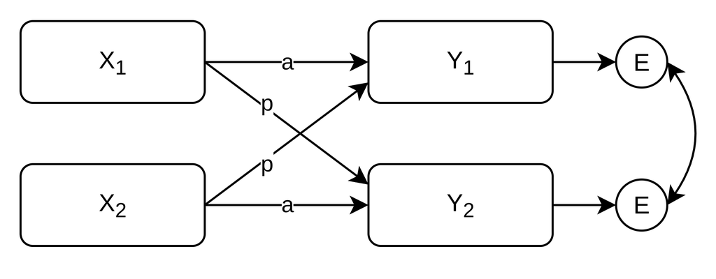

(e.g., del Rosario & West, 2025; Kenny & Ackerman, 2023)

## Exchangeable Dyads - Cross-Sectional APIM

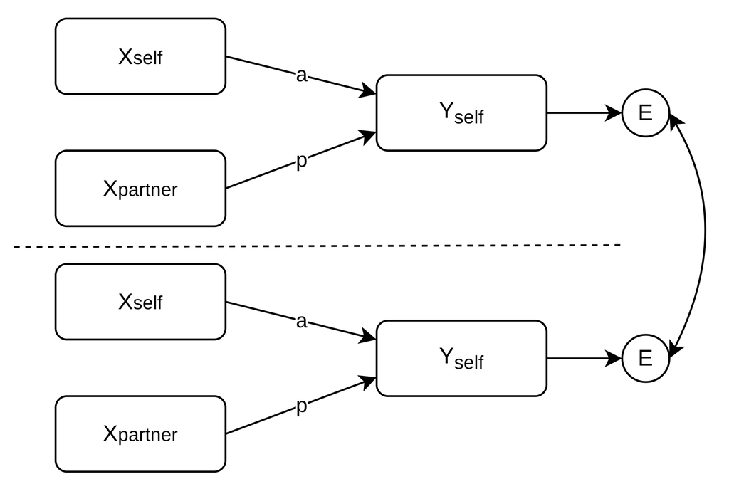

(e.g., del Rosario & West, 2025; Kenny & Ackerman, 2023)

## Exchangeable Dyads - Main Assumptions

Partners are exchangeable, i.e., not *systematically* different.

- Equal actor effects
- Equal partner effects
- Equal means
- Equal residual variances

But they should still be allowed to vary within each couple, while being correlated.

(e.g., del Rosario & West, 2025; Kenny & Ackerman, 2023)

## Exchangeable Dyads - Cross-Sectional APIM: Assumption

Exchangeability is a modelling constraint, not a claim that the dyads are truly exchangeable. To test that constraint, fit both models to the same prepared observations.

## Exchangeable Dyads - Cross-Sectional APIM: Preparation

```r
# Reuse the distinguishable preparation, including its arbitrary
# -1/+1 member contrast.
df_exchangeable_apim <- df_apim
```

## Exchangeable Dyads - Cross-Sectional APIM: Prepared Data

```r
print_apim_preview(df_exchangeable_apim)
```

| userID | coupleID | gender | .is_male | .is_female | .member_contrast_arbitrary | satisfaction | .communication_gmc_actor | .communication_gmc_partner |
| --- | --- | --- | --- | --- | --- | --- | --- | --- |
| 1_1 | 1 | female | 0 | 1 | -1 | 4.841332 | -0.1553604 | 0.9980657 |
| 1_2 | 1 | male | 1 | 0 | 1 | 5.577165 | 0.9980657 | -0.1553604 |
| 2_1 | 2 | female | 0 | 1 | -1 | 7.248741 | 0.8748537 | 1.4272563 |
| 2_2 | 2 | male | 1 | 0 | 1 | 6.960293 | 1.4272563 | 0.8748537 |
| 3_1 | 3 | female | 0 | 1 | -1 | 6.928699 | -0.7224960 | 0.5095933 |
| 3_2 | 3 | male | 1 | 0 | 1 | 6.077688 | 0.5095933 | -0.7224960 |

## Exchangeable Dyads - Cross-Sectional APIM: glmmTMB

- For the fixed effects, we can pool the intercepts `.is_male` and `.is_female` by simply reintroducing a single shared intercept `1`.
- For the actor and partner effects, we can remove the interactions to get a pooled estimate.
- For the residual, we want to constrain both partners’ variances to be equal. Often, this is attempted via: `(1 | coupleID)`.
  - This gives both partners the same dyad-level random intercept variance.
  - With the usual Gaussian residual variance still present, the implied partner correlation is positive but not freely estimated: $\frac{\tau^2}{\tau^2 + \sigma^2}$.
  - If residual variance is removed with `dispformula = ~ 0`, the shared random intercept would imply a correlation near 1, which is too restrictive.

## Exchangeable Dyads - Cross-Sectional APIM: glmmTMB

One solution in glmmTMB is the following:

```r
model_exch_apim_glmmtmb <- glmmTMB(
  satisfaction ~

    # Pooled single intercept
    1 +

    # Pooled actor and partner effects
    .communication_gmc_actor + .communication_gmc_partner +

    # Independent common and member-deviation terms parameterize a homogeneous
    # two-member covariance using dyadMLM's arbitrary contrast.
    (1 | coupleID) + (0 + .member_contrast_arbitrary | coupleID)

    # The dyadic covariance is represented by the two random-effect blocks, so
    # remove the additional independent Gaussian residual variance.
    , dispformula = ~ 0

    , data = df_exchangeable_apim
    , family = gaussian()
)
```

## Exchangeable APIM - Covariance Recovery

`recover_exchangeable_covariance()` back-transforms the common and deviation blocks to the homogeneous member variance and partner correlation:

```
Recovered exchangeable member-level covariance

Pair `pair_1`
Shared:     us(1 | coupleID)
Difference: us(0 + .member_contrast_arbitrary | coupleID)

Variance-covariance:
                       1     2
1 member1: (Intercept) 2.403 0.827
2 member2: (Intercept) 0.827 2.403

Standard deviations and correlations:
                       1     2
1 member1: (Intercept) 1.550 0.344
2 member2: (Intercept) 0.344 1.550
```

## Exchangeable Dyads - Cross-Sectional APIM: Interpreting the Covariance

Let $\tau_c^2$ be the variance of the common intercept and $\tau_d^2$ the variance of the independent member deviation. With `.member_contrast_arbitrary = -1/+1`, the back-transformation is

$$\operatorname{Var}(e_1)=\operatorname{Var}(e_2)=\tau_c^2+\tau_d^2,$$

$$\operatorname{Cov}(e_1,e_2)=\tau_c^2-\tau_d^2,
\qquad
\rho=\frac{\tau_c^2-\tau_d^2}{\tau_c^2+\tau_d^2}.$$

The model can therefore represent negative partner correlation when $\tau_d^2>\tau_c^2$ (del Rosario & West, 2025). For repeated measures, index the same structure at the couple-day level.

## Exchangeable Dyads - Cross-Sectional APIM: brms

In brms, this issue can be solved more easily with a native residual correlation structure and one pooled residual variance:

```r
formula_exch_apim <- bf(
  satisfaction ~ 1 +
    .communication_actor + .communication_partner +

    # To achieve a homogeneous two-partner covariance structure we use an
    # unstructured residual correlation over the two member positions.
    unstr(time = .member_contrast_arbitrary, gr = coupleID)

  # ... but now, we do not allow individual variances anymore.
  # We want one pooled residual variance. So we do not specify a sigma formula.
  # This implies:
  # , sigma = ~ 1
)

priors_exch_apim <- c(
  prior(normal(2, 10), class = "Intercept"),
  prior(normal(0, 5), class = "b"),
  prior(student_t(3, 0, 1.5), class = "sigma"),
  prior(lkj(2), class = "cortime")
)

model_exch_apim <- brm(
  formula = formula_exch_apim,
  data = df_exchangeable_apim,
  family = gaussian(link = identity),
  prior = priors_exch_apim,
  chains = 4,
  cores = 4,
  iter = 2000,
  warmup = 1000,
  seed = 123,
  file = file.path('brms_cache', 'example1_ind_apim') # Cache the model
)
```

## Exchangeable Dyads - Cross-Sectional APIM: Results

|  | Est. | 95% CI | Rhat | Bulk_ESS | Tail_ESS |
| --- | --- | --- | --- | --- | --- |
| **Fixed Effects** |  |  |  |  |  |
| Intercept | -4.71 | [-5.13, -4.26] | 1.004 | 4681 | 2769 |
| .communication_actor | 1.72 | [ 1.66, 1.78] | 1.002 | 4425 | 2895 |
| .communication_partner | 0.24 | [ 0.18, 0.30] | 1.000 | 4971 | 3242 |
| **Residual Structure** |  |  |  |  |  |
| cortime(-1,1) | 0.34 | [0.26, 0.42] | 1.000 | 4665 | 3140 |
| sigma | 1.55 | [1.49, 1.63] | 1.001 | 4114 | 3191 |

## Constraints vs Prediction

`compare_nested_models()` tests the imposed exchangeability constraints with a likelihood-ratio comparison:

```
Likelihood-ratio test for nested models fitted to equivalent data
Assumes mathematical nesting and an appropriate chi-squared reference distribution.

                        Df    AIC    BIC  logLik deviance  Chisq Chi Df Pr(>Chisq)
model_exch_apim_glmmtmb  5 4026.6 4051.7 -2008.3   4016.6
model_dist_apim_glmmtmb  9 3776.7 3821.7 -1879.3   3758.7 257.95      4  < 2.2e-16 ***
---
Signif. codes:  0 '***' 0.001 '**' 0.01 '*' 0.05 '.' 0.1 ' ' 1

Conclusion (5% level): The likelihood-ratio test provides evidence that `model_dist_apim_glmmtmb` fits better than `model_exch_apim_glmmtmb` (p < 0.001).
```

The following observation-level PSIS-LOO comparison instead evaluates conditional predictive performance (Bürkner et al., 2021). It is not a formal test of distinguishability or prediction of a new dyad.

## Exchangeable Dyads - APIM: LOO Comparison

| Model | elpd_diff | se_diff |
| --- | --- | --- |
| distinguishable | 0.0 | 0.0 |
| exchangeable | -172.9 | 16.5 |

For this observation-level target, the distinguishable model predicts better. The ELPD difference is descriptive predictive evidence; `se_diff` summarizes its uncertainty (Sivula et al., 2025; Vehtari et al., 2017).

## Exchangeable Dyads - Cross-Sectional DIM

[interactive chart not shown]

## Exchangeable Dyads - Cross-Sectional DIM: Data

For the DIM parameterization, prepare the raw observations under the exchangeability assumption.

| userID | coupleID | satisfaction | communication | .communication_dyad_mean_gmc | .communication_within_dyad_dev | .member_contrast_arbitrary |
| --- | --- | --- | --- | --- | --- | --- |
| 1_1 | 1 | 4.841332 | 4.851107 | 0.4213527 | -0.5767130 | -1 |
| 1_2 | 1 | 5.577165 | 6.004533 | 0.4213527 | 0.5767130 | 1 |
| 2_1 | 2 | 7.248741 | 5.881321 | 1.1510550 | -0.2762013 | -1 |
| 2_2 | 2 | 6.960293 | 6.433723 | 1.1510550 | 0.2762013 | 1 |
| 3_1 | 3 | 6.928699 | 4.283971 | -0.1064514 | -0.6160447 | -1 |
| 3_2 | 3 | 6.077688 | 5.516060 | -0.1064514 | 0.6160447 | 1 |

## Exchangeable Dyads - Cross-Sectional DIM: Centering

Decompose `communication` variance into:

- **Between-couple** (cbc): Couple-mean communication skills in relation to other couples
- **Within-couple** (cwc): Individuals’ communication skills in relation to their couple-mean

Same assumption about exchangeability as in the APIM

## Exchangeable Dyads - Cross-Sectional DIM: Centering

- `.communication_dyad_mean_gmc`: the grand-mean-centered dyad mean
- `.communication_within_dyad_dev`: each member’s deviation from that dyad mean

## Exchangeable Dyads - Cross-Sectional DIM: Centering

| userID | coupleID | satisfaction | .communication_dyad_mean_gmc | .communication_within_dyad_dev | .member_contrast_arbitrary |
| --- | --- | --- | --- | --- | --- |
| 1_1 | 1 | 4.841332 | 0.4213527 | -0.5767130 | -1 |
| 1_2 | 1 | 5.577165 | 0.4213527 | 0.5767130 | 1 |
| 2_1 | 2 | 7.248741 | 1.1510550 | -0.2762013 | -1 |
| 2_2 | 2 | 6.960293 | 1.1510550 | 0.2762013 | 1 |
| 3_1 | 3 | 6.928699 | -0.1064514 | -0.6160447 | -1 |
| 3_2 | 3 | 6.077688 | -0.1064514 | 0.6160447 | 1 |

## Exchangeable Dyads - Cross-Sectional DIM: Model

```r
formula_exch_dim <- bf(
  satisfaction ~ 1 +
    .communication_dyad_mean_gmc + .communication_within_dyad_dev +
    unstr(time = .member_contrast_arbitrary, gr = coupleID)

    # sigma ~ 1 is implied.
)

priors_exch_dim <- c(
  prior(normal(2, 10), class = "Intercept"),
  prior(normal(0, 5), class = "b"),
  prior(student_t(3, 0, 1.5), class = "sigma"),
  prior(lkj(2), class = "cortime")
)

model_exch_dim <- brm(
  formula = formula_exch_dim,
  data = df_exchangeable_dim,
  family = gaussian(link = identity),
  prior = priors_exch_dim,
  chains = 4,
  cores = 4,
  iter = 2000,
  warmup = 1000,
  seed = 123,
  file = file.path('brms_cache', 'example1_ind_dim') # Cache the model
)
```

## Exchangeable Dyads - Cross-Sectional DIM: Results

|  | Est. | 95% CI | Rhat | Bulk_ESS | Tail_ESS |
| --- | --- | --- | --- | --- | --- |
| **Fixed Effects** |  |  |  |  |  |
| Intercept | 5.11 | [5.00, 5.22] | 1.001 | 4390 | 2769 |
| .communication_dyad_mean_gmc | 1.96 | [1.87, 2.05] | 1.003 | 4658 | 3120 |
| .communication_within_dyad_dev | 1.48 | [1.39, 1.57] | 1.002 | 4285 | 2998 |
| **Residual Structure** |  |  |  |  |  |
| cortime(-1,1) | 0.34 | [0.27, 0.42] | 1.001 | 4164 | 2873 |
| sigma | 1.55 | [1.49, 1.62] | 1.000 | 4560 | 3396 |

## Equivalence APIM and DIM

`dyadMLM` grand-mean centers the DIM dyad mean, whereas these APIM predictors are raw. APIM and DIM slopes require the sum/difference transformations shown later; their residual covariance is directly comparable. The printed intercepts also use different origins, so shift the APIM intercept to average communication before comparing it (Bolger et al., 2025):

$$b_{0,\,APIM(GMC)} = b_{0,\,APIM(raw)} + \bar{x}
(b_{actor} + b_{partner}).$$

|  | Est. | 95% CI |
| --- | --- | --- |
| **Fixed Effects** |  |  |
| Intercept | -4.71 | [-5.13, -4.26] |
| .communication_actor | 1.72 | [ 1.66, 1.78] |
| .communication_partner | 0.24 | [ 0.18, 0.30] |
| **Residual Structure** |  |  |
| cortime(-1,1) | 0.34 | [0.26, 0.42] |
| sigma | 1.55 | [1.49, 1.63] |

|  | Est. | 95% CI |
| --- | --- | --- |
| **Fixed Effects** |  |  |
| Intercept | 5.11 | [5.00, 5.22] |
| .communication_dyad_mean_gmc | 1.96 | [1.87, 2.05] |
| .communication_within_dyad_dev | 1.48 | [1.39, 1.57] |
| **Residual Structure** |  |  |
| cortime(-1,1) | 0.34 | [0.27, 0.42] |
| sigma | 1.55 | [1.49, 1.62] |

## Equivalence APIM and DIM

|  | Est. | 95% CI |
| --- | --- | --- |
| **Fixed Effects** |  |  |
| Intercept | -4.71 | [-5.13, -4.26] |
| .communication_actor | 1.72 | [ 1.66, 1.78] |
| .communication_partner | 0.24 | [ 0.18, 0.30] |

|  | Est. | 95% CI |
| --- | --- | --- |
| **Fixed Effects** |  |  |
| Intercept | 5.11 | [5.00, 5.22] |
| .communication_dyad_mean_gmc | 1.96 | [1.87, 2.05] |
| .communication_within_dyad_dev | 1.48 | [1.39, 1.57] |

Top sliders: grand-mean-centered *Communication* for **Actor** and **Partner** (APIM).  
Bottom sliders: reparameterized communication — **Centered Between-Couple** (`xcbc`) and **Centered Within-Couple** (`xcwc`) (DIM).

x<sub>actor_gmc</sub> 0.00 x<sub>partner_gmc</sub> 0.00 x<sub>cbc</sub> 0.00 x<sub>cwc</sub> 0.00

## Equivalence APIM and DIM

### Coordinate Inputs

APIM: individual coordinates

Actor predictor, x<sub>actor</sub> 0.0

Partner predictor, x<sub>partner</sub> 0.0

DIM: mean and deviation coordinates

Couple mean, x<sub>cbc</sub> 0.0

Couple deviation, x<sub>cwc</sub> 0.0

x<sub>cbc</sub> = (x<sub>actor</sub> + x<sub>partner</sub>) / 2

x<sub>cwc</sub> = (x<sub>actor</sub> − x<sub>partner</sub>) / 2

APIM

DIM

Coefficients

**Between-couple effect: the mean.** If both partners increase by 1, the couple mean increases by 1 and the deviation stays 0.

b<sub>cbc</sub> = b<sub>actor</sub> + b<sub>partner</sub>

**Within-couple effect: the deviation.** If the actor increases by 1 and the partner decreases by 1, the couple mean stays 0 and the deviation increases by 1.

b<sub>cwc</sub> = b<sub>actor</sub> − b<sub>partner</sub>

The dot lives in APIM space: horizontal = actor predictor, vertical = partner predictor. The diagonal axes show the same point in DIM space.

## Equivalence APIM and DIM

- If the couple mean goes up by 1 and the within-couple deviation from the couple mean stays fixed, this means that both partners’ predictors must go up by 1 unit. Thus, the effects are linear combinations:

$$b_{cbc} = b_{actor} + b_{partner}$$

- Similarly, if a person’s deviation from their couple mean is one unit higher and the couple mean stays fixed, this means their partners’ deviation must be one unit lower. Thus, the effects are a linear combination:

$$b_{cwc} = b_{actor} - b_{partner}$$

(Bolger et al., 2025)

## Equivalence APIM and DIM

- Conversely, to obtain the actor and partner effects given the DIM estimates:

$$b_{actor} = \frac{b_{cbc} + b_{cwc}}{2}$$

$$b_{partner} = \frac{b_{cbc} - b_{cwc}}{2}$$

## Equivalence APIM and DIM

Example: using APIM coefficients to obtain DIM coefficients and computing *Credible Intervals* of DIM coefficients.

```r
a <- hypothesis(
  model_exch_apim,
  ".communication_actor + .communication_partner = 0"
)

round(a$hypothesis[,c(2,3,4,5)], 2)
```

```
  Estimate Est.Error CI.Lower CI.Upper
1     1.96      0.04     1.87     2.04
```

|  | Est. | 95% CI |
| --- | --- | --- |
| **Fixed Effects** |  |  |
| Intercept | -4.71 | [-5.13, -4.26] |
| .communication_actor | 1.72 | [ 1.66, 1.78] |
| .communication_partner | 0.24 | [ 0.18, 0.30] |

|  | Est. | 95% CI |
| --- | --- | --- |
| **Fixed Effects** |  |  |
| Intercept | 5.11 | [5.00, 5.22] |
| .communication_dyad_mean_gmc | 1.96 | [1.87, 2.05] |
| .communication_within_dyad_dev | 1.48 | [1.39, 1.57] |

## Equivalence APIM and DIM: Takeaway

- **APIM** and **DIM** are likelihood reparametrizations of the same model (aside from prior impact in Bayesian fits)
- **APIM**: intuitive actor/partner framing
- **DIM**: clean separation of between vs within components
- Estimating one model allows for directly obtaining estimates of the other
- Same random-effects structure at dyad level and same assumptions

### Side Note:

In the **distinguishable** case, the full **Dyadic Score Model (DSM)** (e.g., Stadler et al., 2023) is equivalent to the corresponding full APIM (aside from prior impact in Bayesian fits) (Bolger et al., 2025; Iida et al., 2018).

## Exchangeable Dyads - L-DIM/L-APIM: Simulated Data

We start again from the raw longitudinal data and omit `role`, which tells `dyadMLM` to treat the two members as exchangeable. Requesting both model types creates the APIM and DIM predictors in the same model-ready object.

```r
df_long_dim <- prepare_dyad_data(
  data = df_long,
  dyad = coupleID,
  member = userID,
  time = diaryday,
  predictors = provided_support,
  model_types = c("apim", "dim"),
  seed = 123
) %>%
  mutate(
    diaryday_c = diaryday - mean(diaryday)
  )
```

| userID | coupleID | diaryday | gender | closeness | provided_support | .composition | .composition_role | .is_exchangeable | .member_contrast_arbitrary | .provided_support_cwp | .provided_support_cbp | .provided_support_actor | .provided_support_partner | .provided_support_cwp_actor | .provided_support_cwp_partner | .provided_support_cbp_actor | .provided_support_cbp_partner | .provided_support_dyad_mean_gmc | .provided_support_within_dyad_dev | .provided_support_cwp_dyad_mean | .provided_support_cwp_within_dyad_dev | .provided_support_cbp_dyad_mean | .provided_support_cbp_within_dyad_dev | diaryday_c |
| --- | --- | --- | --- | --- | --- | --- | --- | --- | --- | --- | --- | --- | --- | --- | --- | --- | --- | --- | --- | --- | --- | --- | --- | --- |
| 31_1 | 31 | 0 | female | 5.47 | 6.02 | assumed_exchangeable | assumed_exchangeable | 1 | -1 | 0.41 | 0.65 | 6.02 | 7.09 | 0.41 | 1.54 | 0.65 | 0.58 | 1.59 | -0.53 | 0.97 | -0.57 | 0.61 | 0.04 | -27 |
| 31_1 | 31 | 1 | female | 7.69 | 6.13 | assumed_exchangeable | assumed_exchangeable | 1 | -1 | 0.51 | 0.65 | 6.13 | 6.95 | 0.51 | 1.4 | 0.65 | 0.58 | 1.57 | -0.41 | 0.96 | -0.44 | 0.61 | 0.04 | -26 |
| 31_1 | 31 | 2 | female | 5.83 | 6.1 | assumed_exchangeable | assumed_exchangeable | 1 | -1 | 0.49 | 0.65 | 6.1 | 6.34 | 0.49 | 0.79 | 0.65 | 0.58 | 1.25 | -0.12 | 0.64 | -0.15 | 0.61 | 0.04 | -25 |
| 31_1 | 31 | 3 | female | 6.55 | 6.99 | assumed_exchangeable | assumed_exchangeable | 1 | -1 | 1.38 | 0.65 | 6.99 | 5.39 | 1.38 | -0.15 | 0.65 | 0.58 | 1.23 | 0.8 | 0.61 | 0.77 | 0.61 | 0.04 | -24 |
| ... | ... | ... | ... | ... | ... | ... | ... | ... | ... | ... | ... | ... | ... | ... | ... | ... | ... | ... | ... | ... | ... | ... | ... | ... |
| 31_2 | 31 | 0 | male | 5.19 | 7.09 | assumed_exchangeable | assumed_exchangeable | 1 | 1 | 1.54 | 0.58 | 7.09 | 6.02 | 1.54 | 0.41 | 0.58 | 0.65 | 1.59 | 0.53 | 0.97 | 0.57 | 0.61 | -0.04 | -27 |
| 31_2 | 31 | 1 | male | 6.96 | 6.95 | assumed_exchangeable | assumed_exchangeable | 1 | 1 | 1.4 | 0.58 | 6.95 | 6.13 | 1.4 | 0.51 | 0.58 | 0.65 | 1.57 | 0.41 | 0.96 | 0.44 | 0.61 | -0.04 | -26 |
| 31_2 | 31 | 2 | male | 6.9 | 6.34 | assumed_exchangeable | assumed_exchangeable | 1 | 1 | 0.79 | 0.58 | 6.34 | 6.1 | 0.79 | 0.49 | 0.58 | 0.65 | 1.25 | 0.12 | 0.64 | 0.15 | 0.61 | -0.04 | -25 |
| 31_2 | 31 | 3 | male | 7.59 | 5.39 | assumed_exchangeable | assumed_exchangeable | 1 | 1 | -0.15 | 0.58 | 5.39 | 6.99 | -0.15 | 1.38 | 0.58 | 0.65 | 1.23 | -0.8 | 0.61 | -0.77 | 0.61 | -0.04 | -24 |

# Exchangeable Dyads - Intensive Longitudinal

## Exchangeable Dyads - Longitudinal DIM/APIM

- We need an APIM or DIM on both the between person level and the within-person level.
- Due to equivalence, we could have a DIM on one level and an APIM on the other.

The generated `.provided_support_cwp_dyad_mean` and `.provided_support_cwp_within_dyad_dev` columns form the within-person DIM. The corresponding `.provided_support_cbp_dyad_mean` and `.provided_support_cbp_within_dyad_dev` columns form the between-person DIM (Bolger & Laurenceau, 2013).

Caveat: these simulated data contain gender differences, which exchangeable models ignore. The member-level variances and correlations reported below absorb these differences, so they do not match the simulated values. The example only illustrates the workflow.

## Exchangeable Dyads - L-DIM/L-APIM: Preparing the Member Contrast

`dyadMLM` generates `.member_contrast_arbitrary` as an arbitrary `-1/+1` member contrast. The fixed seed makes that assignment reproducible.

## Exchangeable Dyads - L-DIM/L-APIM: Preparing the Member Contrast

| userID | coupleID | diaryday | gender | closeness | provided_support | .composition | .composition_role | .is_exchangeable | .member_contrast_arbitrary | .provided_support_cwp | .provided_support_cbp | .provided_support_actor | .provided_support_partner | .provided_support_cwp_actor | .provided_support_cwp_partner | .provided_support_cbp_actor | .provided_support_cbp_partner | .provided_support_dyad_mean_gmc | .provided_support_within_dyad_dev | .provided_support_cwp_dyad_mean | .provided_support_cwp_within_dyad_dev | .provided_support_cbp_dyad_mean | .provided_support_cbp_within_dyad_dev | diaryday_c |
| --- | --- | --- | --- | --- | --- | --- | --- | --- | --- | --- | --- | --- | --- | --- | --- | --- | --- | --- | --- | --- | --- | --- | --- | --- |
| 31_1 | 31 | 0 | female | 5.47 | 6.02 | assumed_exchangeable | assumed_exchangeable | 1 | -1 | 0.41 | 0.65 | 6.02 | 7.09 | 0.41 | 1.54 | 0.65 | 0.58 | 1.59 | -0.53 | 0.97 | -0.57 | 0.61 | 0.04 | -27 |
| 31_1 | 31 | 1 | female | 7.69 | 6.13 | assumed_exchangeable | assumed_exchangeable | 1 | -1 | 0.51 | 0.65 | 6.13 | 6.95 | 0.51 | 1.4 | 0.65 | 0.58 | 1.57 | -0.41 | 0.96 | -0.44 | 0.61 | 0.04 | -26 |
| 31_1 | 31 | 2 | female | 5.83 | 6.1 | assumed_exchangeable | assumed_exchangeable | 1 | -1 | 0.49 | 0.65 | 6.1 | 6.34 | 0.49 | 0.79 | 0.65 | 0.58 | 1.25 | -0.12 | 0.64 | -0.15 | 0.61 | 0.04 | -25 |
| 31_1 | 31 | 3 | female | 6.55 | 6.99 | assumed_exchangeable | assumed_exchangeable | 1 | -1 | 1.38 | 0.65 | 6.99 | 5.39 | 1.38 | -0.15 | 0.65 | 0.58 | 1.23 | 0.8 | 0.61 | 0.77 | 0.61 | 0.04 | -24 |
| 31_1 | 31 | 4 | female | 7.03 | 6.7 | assumed_exchangeable | assumed_exchangeable | 1 | -1 | 1.08 | 0.65 | 6.7 | 5.19 | 1.08 | -0.36 | 0.65 | 0.58 | 0.97 | 0.75 | 0.36 | 0.72 | 0.61 | 0.04 | -23 |
| ... | ... | ... | ... | ... | ... | ... | ... | ... | ... | ... | ... | ... | ... | ... | ... | ... | ... | ... | ... | ... | ... | ... | ... | ... |
| 31_2 | 31 | 0 | male | 5.19 | 7.09 | assumed_exchangeable | assumed_exchangeable | 1 | 1 | 1.54 | 0.58 | 7.09 | 6.02 | 1.54 | 0.41 | 0.58 | 0.65 | 1.59 | 0.53 | 0.97 | 0.57 | 0.61 | -0.04 | -27 |
| 31_2 | 31 | 1 | male | 6.96 | 6.95 | assumed_exchangeable | assumed_exchangeable | 1 | 1 | 1.4 | 0.58 | 6.95 | 6.13 | 1.4 | 0.51 | 0.58 | 0.65 | 1.57 | 0.41 | 0.96 | 0.44 | 0.61 | -0.04 | -26 |
| 31_2 | 31 | 2 | male | 6.9 | 6.34 | assumed_exchangeable | assumed_exchangeable | 1 | 1 | 0.79 | 0.58 | 6.34 | 6.1 | 0.79 | 0.49 | 0.58 | 0.65 | 1.25 | 0.12 | 0.64 | 0.15 | 0.61 | -0.04 | -25 |
| 31_2 | 31 | 3 | male | 7.59 | 5.39 | assumed_exchangeable | assumed_exchangeable | 1 | 1 | -0.15 | 0.58 | 5.39 | 6.99 | -0.15 | 1.38 | 0.58 | 0.65 | 1.23 | -0.8 | 0.61 | -0.77 | 0.61 | -0.04 | -24 |
| 31_2 | 31 | 4 | male | 7.55 | 5.19 | assumed_exchangeable | assumed_exchangeable | 1 | 1 | -0.36 | 0.58 | 5.19 | 6.7 | -0.36 | 1.08 | 0.58 | 0.65 | 0.97 | -0.75 | 0.36 | -0.72 | 0.61 | -0.04 | -23 |

## Exchangeable Dyads - L-DIM/L-APIM: glmmTMB

```r
model_exch_long_apim_glmmtmb <- glmmTMB(
  closeness ~ 1 +

    diaryday_c +

    # Within-person APIM
    .provided_support_cwp_actor +
    .provided_support_cwp_partner +
    # Equivalent to within-person DIM:
    # .provided_support_cwp_dyad_mean +
    # .provided_support_cwp_within_dyad_dev +

    # Between-person APIM
    .provided_support_cbp_actor +
    .provided_support_cbp_partner +
    # Equivalent to between-person DIM
    # .provided_support_cbp_within_dyad_dev +
    # .provided_support_cbp_dyad_mean +

    # Dyad-Level intercept and slopes for time-varying predictors
    (1 + diaryday_c + .provided_support_cwp_actor + .provided_support_cwp_partner | coupleID) +

    # Both partners' deviations from these dyad-level means and slopes.
    # Note: separate random-effects block to make them uncorrelated with dyad-level REs.
    (0 + .member_contrast_arbitrary +
         I(.member_contrast_arbitrary * diaryday_c) +
         I(.member_contrast_arbitrary * .provided_support_cwp_actor) +
         I(.member_contrast_arbitrary * .provided_support_cwp_partner) | coupleID) +

    # After accounting for stable differences between partners, they may still be
    # non-independent each day due to external occurrences and daily exchange processes
    # not captured in the fixed effects. Thus, residuals are not yet independent.
    # Homogeneous same-day residual covariance between partners:
    (1 | coupleID:diaryday) +
      (0 + .member_contrast_arbitrary | coupleID:diaryday)

  # For this Gaussian model, remove the additional independent residual
  # variance because the two couple-day blocks represent it.
  , dispformula = ~ 0
  , data = df_long_dim
)
```

## Exchangeable Dyads - L-DIM/L-APIM: glmmTMB

In this example, the glmmTMB model does not converge properly. The random-effects structure is too complex for the information available in these data, so we would have to simplify it. Instead, we use brms below.

## Exchangeable Dyads - L-DIM/L-APIM: brms

In brms, the same model can be estimated as:

Unlike the distinguishable longitudinal model, this exchangeable specification keeps one pooled residual `sigma` (`sigma ~ 1` is implied). Its residual SD prior therefore targets `class = "sigma"` directly.

```r
formula_exch_long_apim <- bf(
  closeness ~ 1 +

    diaryday_c +

    # Within-person APIM
    .provided_support_cwp_actor +
    .provided_support_cwp_partner +

    # Between-person APIM
    .provided_support_cbp_actor +
    .provided_support_cbp_partner +

    # Dyad-Level intercept and slopes for time-varying predictors
    (1 + diaryday_c + .provided_support_cwp_actor + .provided_support_cwp_partner | coupleID) +

    # Both partners' deviations from these dyad-level means and slopes.
    # Note: separate random-effects block to make them uncorrelated with dyad-level REs.
    (0 + .member_contrast_arbitrary +
         I(.member_contrast_arbitrary * diaryday_c) +
         I(.member_contrast_arbitrary * .provided_support_cwp_actor) +
         I(.member_contrast_arbitrary * .provided_support_cwp_partner) | coupleID) +

    # Modelling Level 1 residuals in brms:
    unstr(time = .member_contrast_arbitrary, gr = coupleID:diaryday)

  # Again, no need to model heterogeneous residual variances (sigma)
  # Implied: sigma = ~ 1
)

priors_exch_long_apim <- c(
  prior(normal(4, 2), class = "Intercept"),
  prior(normal(0, 2), class = "b"),
  prior(exponential(1), class = "sd"),
  prior(lkj(2), class = "cor"),
  prior(student_t(3, 0, 1.5), class = "sigma"),
  prior(lkj(2), class = "cortime")
)

model_exch_long_apim <- brm(
  formula = formula_exch_long_apim,
  data = df_long_dim,
  family = gaussian(link = identity),
  prior = priors_exch_long_apim,
  chains = 4,
  cores = 4,
  iter = 2000,
  warmup = 1000,
  seed = 123,
  file = file.path('brms_cache', 'model_apim_ind_long_apim')
)
```

## Exchangeable Dyads - L-DIM/L-APIM: brms

The equivalent DIM specification:

```r
# DIM Version
formula_exch_long_dim <- bf(
  closeness ~ 1 +

    diaryday_c +

    .provided_support_cwp_dyad_mean +
    .provided_support_cwp_within_dyad_dev +

    .provided_support_cbp_dyad_mean +
    .provided_support_cbp_within_dyad_dev +

    (1 + diaryday_c + .provided_support_cwp_actor + .provided_support_cwp_partner | coupleID) +
    (0 + .member_contrast_arbitrary +
         I(.member_contrast_arbitrary * diaryday_c) +
         I(.member_contrast_arbitrary * .provided_support_cwp_actor) +
         I(.member_contrast_arbitrary * .provided_support_cwp_partner) | coupleID) +

    unstr(time = .member_contrast_arbitrary, gr = coupleID:diaryday)
)

priors_exch_long_dim <- c(
  prior(normal(4, 2), class = "Intercept"),
  prior(normal(0, 2), class = "b"),
  prior(exponential(1), class = "sd"),
  prior(lkj(2), class = "cor"),
  prior(student_t(3, 0, 1.5), class = "sigma"),
  prior(lkj(2), class = "cortime")
)

model_exch_long_dim <- brm(
  formula = formula_exch_long_dim,
  data = df_long_dim,
  family = gaussian(link = identity),
  prior = priors_exch_long_dim,
  chains = 4,
  cores = 4,
  iter = 2000,
  warmup = 1000,
  seed = 123,
  file = file.path('brms_cache', 'model_apim_ind_long_dim')
)
```

## Exchangeable Dyads - L-DIM/L-APIM: Member-Contrast Coding

For appropriate exchangeable random effects, we can use the generated `.member_contrast_arbitrary` column (del Rosario & West, 2025; Kenny & Ackerman, 2023):

- Randomly give one partner a constant of -1 and the other a constant of 1
- The couple-level intercept represents the average/common intercept of the two partners. `(1 | coupleID)`
- A column of 1s and -1s represents each partner’s deviation from the couple-level effect, with partners contributing equally in opposite directions (+1 and -1)

Exchangeability is retained: if partners are flipped, the result is the same.

(del Rosario & West (2025) provide practical guidance on how to reduce the random effects structure in case of non-convergence.)

## Exchangeable Dyads - L-DIM/L-APIM: Common and Deviation Components

For two partners coded with `.member_contrast_arbitrary = +1` and `.member_contrast_arbitrary = -1`, the glmmTMB structure `(1 | coupleID:diaryday) + (0 + .member_contrast_arbitrary | coupleID:diaryday)` uses independent common and member-deviation components to imply a homogeneous two-partner residual covariance.

This requires exactly two rows per couple-day and independent common and deviation blocks, and `dispformula = ~ 0`. If their variances are $\tau_c^2$ and $\tau_d^2$, member variance is $\tau_c^2+\tau_d^2$, covariance is $\tau_c^2-\tau_d^2$, and their ratio is the correlation. No manual partner indicators are needed (del Rosario & West, 2025).

## Exchangeable Dyads - L-DIM/L-APIM: Results

Comparing APIM (left) and DIM (right) output of fixed effects.

|  | Est. | 95% CI |
| --- | --- | --- |
| **Fixed Effects** |  |  |
| Intercept | 5.10 | [4.97, 5.24] |
| diaryday_c | 0.00 | [0.00, 0.01] |
| .provided_support_cwp_actor | 0.30 | [0.27, 0.33] |
| .provided_support_cwp_partner | 0.15 | [0.12, 0.18] |
| .provided_support_cbp_actor | 1.32 | [1.14, 1.48] |
| .provided_support_cbp_partner | 0.38 | [0.21, 0.56] |

|  | Est. | 95% CI |
| --- | --- | --- |
| **Fixed Effects** |  |  |
| Intercept | 5.11 | [4.98, 5.23] |
| diaryday_c | 0.00 | [0.00, 0.01] |
| .provided_support_cwp_dyad_mean | 0.45 | [0.41, 0.49] |
| .provided_support_cwp_within_dyad_dev | 0.15 | [0.11, 0.19] |
| .provided_support_cbp_dyad_mean | 1.70 | [1.55, 1.86] |
| .provided_support_cbp_within_dyad_dev | 0.93 | [0.61, 1.21] |

- Equivalence holds on both levels. Numeric deviations arise due to priors, sampling noise, and rounding.

## Exchangeable Dyads - L-DIM/L-APIM: Results

APIM Results in Detail:

|  | Est. | 95% CI | Rhat | Bulk_ESS | Tail_ESS |
| --- | --- | --- | --- | --- | --- |
| **Fixed Effects** |  |  |  |  |  |
| Intercept | 5.10 | [4.97, 5.24] | 1.017 | 175 | 225 |
| diaryday_c | 0.00 | [0.00, 0.01] | 1.005 | 463 | 1553 |
| .provided_support_cwp_actor | 0.30 | [0.27, 0.33] | 1.001 | 2845 | 2572 |
| .provided_support_cwp_partner | 0.15 | [0.12, 0.18] | 1.000 | 3249 | 2819 |
| .provided_support_cbp_actor | 1.32 | [1.14, 1.48] | 1.017 | 171 | 286 |
| .provided_support_cbp_partner | 0.38 | [0.21, 0.56] | 1.005 | 212 | 492 |
| **Random Effects** |  |  |  |  |  |
| sd(Intercept) | 0.67 | [ 0.58, 0.77] | 1.022 | 389 | 702 |
| sd(diaryday_c) | 0.01 | [ 0.01, 0.01] | 1.001 | 1581 | 2780 |
| sd(.provided_support_cwp_actor) | 0.05 | [ 0.01, 0.09] | 1.004 | 990 | 953 |
| sd(.provided_support_cwp_partner) | 0.08 | [ 0.04, 0.12] | 1.002 | 1158 | 1197 |
| sd(.member_contrast_arbitrary) | 0.84 | [ 0.74, 0.97] | 1.049 | 218 | 539 |
| sd(I.member_contrast_arbitraryMUdiaryday_c) | 0.01 | [ 0.01, 0.02] | 1.010 | 1152 | 1947 |
| sd(I.member_contrast_arbitraryMU.provided_support_cwp_actor) | 0.14 | [ 0.11, 0.18] | 1.004 | 1154 | 2284 |
| sd(I.member_contrast_arbitraryMU.provided_support_cwp_partner) | 0.07 | [ 0.01, 0.11] | 1.004 | 754 | 627 |
| cor(Intercept,diaryday_c) | 0.56 | [ 0.38, 0.70] | 1.004 | 1129 | 1909 |
| cor(Intercept,.provided_support_cwp_actor) | 0.49 | [ 0.02, 0.82] | 1.002 | 2958 | 2405 |
| cor(diaryday_c,.provided_support_cwp_actor) | 0.37 | [-0.10, 0.76] | 1.002 | 2789 | 2668 |
| cor(Intercept,.provided_support_cwp_partner) | 0.21 | [-0.12, 0.53] | 1.001 | 2870 | 2182 |
| cor(diaryday_c,.provided_support_cwp_partner) | 0.19 | [-0.19, 0.54] | 1.003 | 2961 | 2724 |
| cor(.provided_support_cwp_actor,.provided_support_cwp_partner) | 0.35 | [-0.27, 0.80] | 1.002 | 687 | 1343 |
| cor(.member_contrast_arbitrary,I.member_contrast_arbitraryMUdiaryday_c) | 0.60 | [ 0.44, 0.73] | 1.014 | 788 | 1455 |
| cor(.member_contrast_arbitrary,I.member_contrast_arbitraryMU.provided_support_cwp_actor) | 0.66 | [ 0.46, 0.81] | 1.004 | 1299 | 1965 |
| cor(I.member_contrast_arbitraryMUdiaryday_c,I.member_contrast_arbitraryMU.provided_support_cwp_actor) | 0.42 | [ 0.15, 0.63] | 1.008 | 1619 | 2359 |
| cor(.member_contrast_arbitrary,I.member_contrast_arbitraryMU.provided_support_cwp_partner) | 0.12 | [-0.29, 0.53] | 1.000 | 2816 | 1776 |
| cor(I.member_contrast_arbitraryMUdiaryday_c,I.member_contrast_arbitraryMU.provided_support_cwp_partner) | 0.11 | [-0.32, 0.55] | 1.003 | 3148 | 1966 |
| cor(I.member_contrast_arbitraryMU.provided_support_cwp_actor,I.member_contrast_arbitraryMU.provided_support_cwp_partner) | 0.34 | [-0.17, 0.76] | 1.000 | 1647 | 2123 |
| **Residual Structure** |  |  |  |  |  |
| cortime(-1,1) | 0.04 | [ 0.01, 0.07] | 1.001 | 4908 | 2263 |
| sigma | 0.94 | [ 0.92, 0.95] | 1.000 | 6231 | 2668 |

## Extract Full APIM Random Effects Variance-Covariance Matrix

We can rotate the random effects structure back to obtain the full APIM Random effects variance-covariance matrix, based on (Kenny & Ackerman, 2023). Just as we would in a SEM model with equality constraints!

For example, the within-partner variance of the random intercept is:

$$\operatorname{Var}(u_{\text{common intercept}}) +
\operatorname{Var}(u_{\text{deviation intercept}})$$

and the cross-partner covariance of both partners’ random intercepts is:

$$\operatorname{Var}(u_{\text{common intercept}}) -
\operatorname{Var}(u_{\text{deviation intercept}})$$

In the model output, the common-intercept variance is labelled `Intercept`, and the deviation-intercept variance is labelled `.member_contrast_arbitrary`. This rotation only holds when the common/couple-mean and member-deviation random effects are uncorrelated. This is why we put them in separate random-effects blocks.

## Extract Full APIM Random Effects Variance-Covariance Matrix

```r
a <- summarize_exchangeable_apim_brms(
  model_exch_long_apim,
  gr = "coupleID",
  deviation_term = ".member_contrast_arbitrary",
  partner_labels = c("PartnerA", "PartnerB")
)
```

## Extract Full APIM Random Effects Variance-Covariance Matrix: Within-Person Matrix

```r
print_df(a$within_person_covariance_matrix)
```

|  | Intercept | diaryday_c | .provided_support_cwp_actor | .provided_support_cwp_partner |
| --- | --- | --- | --- | --- |
| Intercept | 1.1802004 | 0.0112332 | 0.0955767 | 0.0179927 |
| diaryday_c | 0.0112332 | 0.0003159 | 0.0010075 | 0.0002727 |
| .provided_support_cwp_actor | 0.0955767 | 0.0010075 | 0.0238464 | 0.0042531 |
| .provided_support_cwp_partner | 0.0179927 | 0.0002727 | 0.0042531 | 0.0118398 |

## Extract Full APIM Random Effects Variance-Covariance Matrix: Cross-Person Matrix

```r
print_df(a$cross_person_covariance_matrix)
```

|  | Intercept | diaryday_c | .provided_support_cwp_actor | .provided_support_cwp_partner |
| --- | --- | --- | --- | --- |
| Intercept | -0.2635988 | -0.0024112 | -0.0630951 | 0.0048753 |
| diaryday_c | -0.0024112 | -0.0000434 | -0.0005769 | 0.0000857 |
| .provided_support_cwp_actor | -0.0630951 | -0.0005769 | -0.0179709 | -0.0015373 |
| .provided_support_cwp_partner | 0.0048753 | 0.0000857 | -0.0015373 | 0.0024947 |

## Extract Full APIM Random Effects Variance-Covariance Matrix: Full Matrix

```r
print_wide_matrix(a$full_covariance_matrix, font_size = 6)
```

|  | PartnerA_Intercept | PartnerA_diaryday_c | PartnerA_.provided_support_cwp_actor | PartnerA_.provided_support_cwp_partner | PartnerB_Intercept | PartnerB_diaryday_c | PartnerB_.provided_support_cwp_actor | PartnerB_.provided_support_cwp_partner |
| --- | --- | --- | --- | --- | --- | --- | --- | --- |
| PartnerA_Intercept | 1.180 | 0.011 | 0.096 | 0.018 | -0.264 | -0.002 | -0.063 | 0.005 |
| PartnerA_diaryday_c | 0.011 | 0.000 | 0.001 | 0.000 | -0.002 | 0.000 | -0.001 | 0.000 |
| PartnerA_.provided_support_cwp_actor | 0.096 | 0.001 | 0.024 | 0.004 | -0.063 | -0.001 | -0.018 | -0.002 |
| PartnerA_.provided_support_cwp_partner | 0.018 | 0.000 | 0.004 | 0.012 | 0.005 | 0.000 | -0.002 | 0.002 |
| PartnerB_Intercept | -0.264 | -0.002 | -0.063 | 0.005 | 1.180 | 0.011 | 0.096 | 0.018 |
| PartnerB_diaryday_c | -0.002 | 0.000 | -0.001 | 0.000 | 0.011 | 0.000 | 0.001 | 0.000 |
| PartnerB_.provided_support_cwp_actor | -0.063 | -0.001 | -0.018 | -0.002 | 0.096 | 0.001 | 0.024 | 0.004 |
| PartnerB_.provided_support_cwp_partner | 0.005 | 0.000 | -0.002 | 0.002 | 0.018 | 0.000 | 0.004 | 0.012 |

The helper function `summarize_exchangeable_apim_brms()` is defined in `00_R_Functions/ReportModels.R`. It rotates every posterior draw, so the interval estimates for the transformed SDs, correlations, covariances, and residual quantities are computed on the transformed scale.

For `glmmTMB`, the same back-transformation is algebraically possible, but interval estimation is less direct because there are no posterior draws. One would usually transform parametric bootstrap draws or asymptotic draws from the fitted parameter covariance matrix.

## Random effects SDs

```r
print_df(
  a$sd_summary %>%
    mutate(across(where(is.numeric), ~ round(.x, 3)))
)
```

| parameter | estimate | est_error | q_low | q_high |
| --- | --- | --- | --- | --- |
| PartnerA_.provided_support_cwp_actor | 0.153 | 0.018 | 0.119 | 0.191 |
| PartnerA_.provided_support_cwp_partner | 0.107 | 0.020 | 0.066 | 0.144 |
| PartnerA_Intercept | 1.085 | 0.056 | 0.987 | 1.206 |
| PartnerA_diaryday_c | 0.018 | 0.001 | 0.016 | 0.020 |
| PartnerB_.provided_support_cwp_actor | 0.153 | 0.018 | 0.119 | 0.191 |
| PartnerB_.provided_support_cwp_partner | 0.107 | 0.020 | 0.066 | 0.144 |
| PartnerB_Intercept | 1.085 | 0.056 | 0.987 | 1.206 |
| PartnerB_diaryday_c | 0.018 | 0.001 | 0.016 | 0.020 |

## Random effect correlation matrix

```r
print_wide_matrix(a$full_correlation_matrix, font_size = 6)
```

|  | PartnerA_Intercept | PartnerA_diaryday_c | PartnerA_.provided_support_cwp_actor | PartnerA_.provided_support_cwp_partner | PartnerB_Intercept | PartnerB_diaryday_c | PartnerB_.provided_support_cwp_actor | PartnerB_.provided_support_cwp_partner |
| --- | --- | --- | --- | --- | --- | --- | --- | --- |
| PartnerA_Intercept | 1.000 | 0.582 | 0.570 | 0.152 | -0.223 | -0.125 | -0.376 | 0.041 |
| PartnerA_diaryday_c | 0.582 | 1.000 | 0.367 | 0.141 | -0.125 | -0.137 | -0.210 | 0.044 |
| PartnerA_.provided_support_cwp_actor | 0.570 | 0.367 | 1.000 | 0.253 | -0.376 | -0.210 | -0.754 | -0.091 |
| PartnerA_.provided_support_cwp_partner | 0.152 | 0.141 | 0.253 | 1.000 | 0.041 | 0.044 | -0.091 | 0.211 |
| PartnerB_Intercept | -0.223 | -0.125 | -0.376 | 0.041 | 1.000 | 0.582 | 0.570 | 0.152 |
| PartnerB_diaryday_c | -0.125 | -0.137 | -0.210 | 0.044 | 0.582 | 1.000 | 0.367 | 0.141 |
| PartnerB_.provided_support_cwp_actor | -0.376 | -0.210 | -0.754 | -0.091 | 0.570 | 0.367 | 1.000 | 0.253 |
| PartnerB_.provided_support_cwp_partner | 0.041 | 0.044 | -0.091 | 0.211 | 0.152 | 0.141 | 0.253 | 1.000 |

## Full reporting summary

```r
section_runs <- rle(a$reporting_summary$section)
section_ends <- cumsum(section_runs$lengths)
section_starts <- section_ends - section_runs$lengths + 1
section_labels <- c(
  "Fixed effects" = "Fixed Effects",
  "Back-transformed random-effect SDs" = "Back-Transformed SDs",
  "Back-transformed random-effect correlations" = "Back-Transformed Correlations",
  "Residual structure" = "Residual Structure"
)
reporting_rows_to_pack <- Map(c, section_starts, section_ends)
names(reporting_rows_to_pack) <- unname(section_labels[section_runs$values])

print_df(
  a$reporting_summary %>%
    mutate(across(where(is.numeric), ~ round(.x, 3))),
  rows_to_pack = reporting_rows_to_pack,
  scroll_height = '50vh'
)
```

| section | parameter | estimate | est_error | q_low | q_high |
| --- | --- | --- | --- | --- | --- |
| **Fixed Effects** |  |  |  |  |  |
| Fixed effects | Intercept | 5.102 | 0.070 | 4.966 | 5.240 |
| Fixed effects | diaryday_c | 0.004 | 0.001 | 0.001 | 0.006 |
| Fixed effects | .provided_support_cwp_actor | 0.300 | 0.014 | 0.273 | 0.328 |
| Fixed effects | .provided_support_cwp_partner | 0.149 | 0.015 | 0.120 | 0.177 |
| Fixed effects | .provided_support_cbp_actor | 1.316 | 0.088 | 1.140 | 1.483 |
| Fixed effects | .provided_support_cbp_partner | 0.382 | 0.086 | 0.212 | 0.557 |
| **Back-Transformed SDs** |  |  |  |  |  |
| Back-transformed random-effect SDs | PartnerA_.provided_support_cwp_actor | 0.153 | 0.018 | 0.119 | 0.191 |
| Back-transformed random-effect SDs | PartnerA_.provided_support_cwp_partner | 0.107 | 0.020 | 0.066 | 0.144 |
| Back-transformed random-effect SDs | PartnerA_Intercept | 1.085 | 0.056 | 0.987 | 1.206 |
| Back-transformed random-effect SDs | PartnerA_diaryday_c | 0.018 | 0.001 | 0.016 | 0.020 |
| Back-transformed random-effect SDs | PartnerB_.provided_support_cwp_actor | 0.153 | 0.018 | 0.119 | 0.191 |
| Back-transformed random-effect SDs | PartnerB_.provided_support_cwp_partner | 0.107 | 0.020 | 0.066 | 0.144 |
| Back-transformed random-effect SDs | PartnerB_Intercept | 1.085 | 0.056 | 0.987 | 1.206 |
| Back-transformed random-effect SDs | PartnerB_diaryday_c | 0.018 | 0.001 | 0.016 | 0.020 |
| **Back-Transformed Correlations** |  |  |  |  |  |
| Back-transformed random-effect correlations | PartnerA_.provided_support_cwp_actor with PartnerA_Intercept | 0.572 | 0.083 | 0.403 | 0.723 |
| Back-transformed random-effect correlations | PartnerA_.provided_support_cwp_actor with PartnerA_diaryday_c | 0.369 | 0.101 | 0.169 | 0.558 |
| Back-transformed random-effect correlations | PartnerA_.provided_support_cwp_partner with PartnerA_.provided_support_cwp_actor | 0.266 | 0.152 | -0.028 | 0.558 |
| Back-transformed random-effect correlations | PartnerA_.provided_support_cwp_partner with PartnerA_Intercept | 0.157 | 0.117 | -0.069 | 0.382 |
| Back-transformed random-effect correlations | PartnerA_.provided_support_cwp_partner with PartnerA_diaryday_c | 0.146 | 0.129 | -0.114 | 0.400 |
| Back-transformed random-effect correlations | PartnerA_diaryday_c with PartnerA_Intercept | 0.581 | 0.056 | 0.470 | 0.681 |
| Back-transformed random-effect correlations | PartnerB_.provided_support_cwp_actor with PartnerA_.provided_support_cwp_actor | -0.755 | 0.151 | -0.983 | -0.412 |
| Back-transformed random-effect correlations | PartnerB_.provided_support_cwp_actor with PartnerA_.provided_support_cwp_partner | -0.096 | 0.160 | -0.412 | 0.215 |
| Back-transformed random-effect correlations | PartnerB_.provided_support_cwp_actor with PartnerA_Intercept | -0.377 | 0.103 | -0.572 | -0.163 |
| Back-transformed random-effect correlations | PartnerB_.provided_support_cwp_actor with PartnerA_diaryday_c | -0.211 | 0.111 | -0.415 | 0.019 |
| Back-transformed random-effect correlations | PartnerB_.provided_support_cwp_actor with PartnerB_Intercept | 0.572 | 0.083 | 0.403 | 0.723 |
| Back-transformed random-effect correlations | PartnerB_.provided_support_cwp_actor with PartnerB_diaryday_c | 0.369 | 0.101 | 0.169 | 0.558 |
| Back-transformed random-effect correlations | PartnerB_.provided_support_cwp_partner with PartnerA_.provided_support_cwp_actor | -0.096 | 0.160 | -0.412 | 0.215 |
| Back-transformed random-effect correlations | PartnerB_.provided_support_cwp_partner with PartnerA_.provided_support_cwp_partner | 0.230 | 0.394 | -0.570 | 0.960 |
| Back-transformed random-effect correlations | PartnerB_.provided_support_cwp_partner with PartnerA_Intercept | 0.043 | 0.125 | -0.199 | 0.281 |
| Back-transformed random-effect correlations | PartnerB_.provided_support_cwp_partner with PartnerA_diaryday_c | 0.046 | 0.138 | -0.231 | 0.310 |
| Back-transformed random-effect correlations | PartnerB_.provided_support_cwp_partner with PartnerB_.provided_support_cwp_actor | 0.266 | 0.152 | -0.028 | 0.558 |
| Back-transformed random-effect correlations | PartnerB_.provided_support_cwp_partner with PartnerB_Intercept | 0.157 | 0.117 | -0.069 | 0.382 |
| Back-transformed random-effect correlations | PartnerB_.provided_support_cwp_partner with PartnerB_diaryday_c | 0.146 | 0.129 | -0.114 | 0.400 |
| Back-transformed random-effect correlations | PartnerB_Intercept with PartnerA_.provided_support_cwp_actor | -0.377 | 0.103 | -0.572 | -0.163 |
| Back-transformed random-effect correlations | PartnerB_Intercept with PartnerA_.provided_support_cwp_partner | 0.043 | 0.125 | -0.199 | 0.281 |
| Back-transformed random-effect correlations | PartnerB_Intercept with PartnerA_Intercept | -0.221 | 0.095 | -0.402 | -0.039 |
| Back-transformed random-effect correlations | PartnerB_Intercept with PartnerA_diaryday_c | -0.124 | 0.084 | -0.288 | 0.040 |
| Back-transformed random-effect correlations | PartnerB_diaryday_c with PartnerA_.provided_support_cwp_actor | -0.211 | 0.111 | -0.415 | 0.019 |
| Back-transformed random-effect correlations | PartnerB_diaryday_c with PartnerA_.provided_support_cwp_partner | 0.046 | 0.138 | -0.231 | 0.310 |
| Back-transformed random-effect correlations | PartnerB_diaryday_c with PartnerA_Intercept | -0.124 | 0.084 | -0.288 | 0.040 |
| Back-transformed random-effect correlations | PartnerB_diaryday_c with PartnerA_diaryday_c | -0.136 | 0.118 | -0.362 | 0.094 |
| Back-transformed random-effect correlations | PartnerB_diaryday_c with PartnerB_Intercept | 0.581 | 0.056 | 0.470 | 0.681 |
| **Residual Structure** |  |  |  |  |  |
| Residual structure | residual_variance | 0.878 | 0.012 | 0.854 | 0.903 |
| Residual structure | same_day_residual_correlation | 0.037 | 0.014 | 0.009 | 0.066 |
| Residual structure | same_day_residual_covariance | 0.033 | 0.012 | 0.008 | 0.058 |
| Residual structure | sigma | 0.937 | 0.007 | 0.924 | 0.950 |

## References

Barr, D. J., Levy, R., Scheepers, C., & Tily, H. J. (2013). Random effects structure for confirmatory hypothesis testing: Keep it maximal. *Journal of Memory and Language*, *68*(3), 255–278. https://doi.org/10.1016/j.jml.2012.11.001

Bolger, N., & Laurenceau, J.-P. (2013). *Intensive longitudinal methods: An introduction to diary and experience sampling research*. Guilford Press. https://www.guilford.com/books/Intensive-Longitudinal-Methods/Bolger-Laurenceau/9781462506781

Bolger, N., Laurenceau, J.-P., & DiGiovanni, A. (2025). Unified analysis model for indistinguishable and distinguishable dyads. *Innovations in Interpersonal Relationships and Health Research: Advancing the Integration of Interdisciplinary Approaches to Dyadic Behavior Change*. https://doi.org/10.17605/OSF.IO/WYDCJ

Brooks, M. E., Kristensen, K., van Benthem, K. J., Magnusson, A., Berg, C. W., Nielsen, A., Skaug, H. J., Maechler, M., & Bolker, B. M. (2017). glmmTMB balances speed and flexibility among packages for zero-inflated generalized linear mixed modeling. *The R Journal*, *9*(2), 378–400. https://doi.org/10.32614/RJ-2017-066

Bürkner, P.-C. (2025). *Brms: Bayesian regression models using stan*. https://github.com/paul-buerkner/brms

Bürkner, P.-C., Gabry, J., & Vehtari, A. (2021). Efficient leave-one-out cross-validation for bayesian non-factorized normal and student-t models. *Computational Statistics*, *36*, 1243–1261. https://doi.org/10.1007/s00180-020-01045-4

del Rosario, K. S., & West, T. V. (2025). A Practical Guide to Specifying Random Effects in Longitudinal Dyadic Multilevel Modeling. *Advances in Methods and Practices in Psychological Science*, *8*(3), 25152459251351286. https://doi.org/10.1177/25152459251351286

Gabry, J., Češnovar, R., Johnson, A., & Bronder, S. (2025). *Cmdstanr: R interface to CmdStan*. https://mc-stan.org/cmdstanr/

Guo, J., Gabry, J., Goodrich, B., Johnson, A., Weber, S., & Badr, H. S. (2025). *Rstan: R interface to stan*. https://mc-stan.org/rstan/

Hartig, F. (2026). *DHARMa: Residual diagnostics for hierarchical (multi-level / mixed) regression models*. http://florianhartig.github.io/DHARMa/

Iida, M., Seidman, G., & Shrout, P. E. (2018). Models of interdependent individuals versus dyadic processes in relationship research. *Journal of Social and Personal Relationships*, *35*(1), 59–88. https://doi.org/10.1177/0265407517725407

Kenny, D. A., & Ackerman, R. A. (2023). *Estimation of random effects with over-time dyadic data using multilevel modeling: The sum and difference method*. OSF. https://osf.io/fju72

Kenny, D. A., & Cook, W. (1999). Partner effects in relationship research: Conceptual issues, analytic difficulties, and illustrations. *Personal Relationships*, *6*(4), 433–448. https://doi.org/10.1111/j.1475-6811.1999.tb00202.x

Kenny, D. A., & Kashy, D. A. (2011). Dyadic Data Analysis Using Multilevel Modeling. In *Handbook of Advanced Multilevel Analysis*. Routledge.

Kenny, D. A., Kashy, D. A., & Cook, W. L. (2006). *Dyadic data analysis*. Guilford Press.

Küng, P. (2026). *dyadMLM: Tools for dyadic multilevel models*. https://doi.org/10.5281/zenodo.21481720

Lüdecke, D., Makowski, D., Ben-Shachar, M. S., Patil, I., Wiernik, B. M., Bacher, E., & Thériault, R. (2026). *Easystats: Framework for easy statistical modeling, visualization, and reporting*. https://easystats.github.io/easystats/

Nickell, S. (1981). Biases in dynamic models with fixed effects. *Econometrica*, *49*(6), 1417–1426. https://doi.org/10.2307/1911408

Pinheiro, J., Bates, D., & R Core Team. (2026). *Nlme: Linear and nonlinear mixed effects models*. https://svn.r-project.org/R-packages/trunk/nlme/

Ripley, B., & Venables, B. (2025). *MASS: Support functions and datasets for venables and ripley’s MASS*. http://www.stats.ox.ac.uk/pub/MASS4/

Sivula, T., Magnusson, M., Matamoros, A. A., & Vehtari, A. (2025). Uncertainty in Bayesian leave-one-out cross-validation based model comparison. *Bayesian Analysis*. https://doi.org/10.1214/25-BA1569

Stadler, G., Scholz, U., Bolger, N., Shrout, P. E., Knoll, N., & Lüscher, J. (2023). How is companionship related to romantic partners’ affect, relationship satisfaction, and health behavior? Using a longitudinal dyadic score model to understand daily and couple-level effects of a dyadic predictor. *Applied Psychology: Health and Well-Being*, *15*(4), 1530–1554. https://doi.org/10.1111/aphw.12450

Vehtari, A., Gabry, J., Magnusson, M., Yao, Y., Bürkner, P.-C., Paananen, T., & Gelman, A. (2025). *Loo: Efficient leave-one-out cross-validation and WAIC for bayesian models*. https://mc-stan.org/loo/

Vehtari, A., Gelman, A., & Gabry, J. (2017). Practical bayesian model evaluation using leave-one-out cross-validation and WAIC. *Statistics and Computing*, *27*, 1413–1432. https://doi.org/10.1007/s11222-016-9696-4

Wickham, H. (2023). *Tidyverse: Easily install and load the tidyverse*. https://tidyverse.tidyverse.org